# Ch. 3: Oil production and ambient air quality in California

Results - Monthly Annuli Active Wells (count, not production volume) (no wind)

## Pollutant: CO

**Notes:**

- We used data from 140 monitors and 17405 monitor-months, from 1999-01-01 to 2019-12-01
- We droppped the 67 monitor-months that had nonsensical mean monthly CO concentrations of ≤ 0 µg/m^3,

### Count of wells

#### Crude model

```
Call:
   felm(formula = monthly_mean_co ~ wells_prod_0to1km + wells_prod_1to2km +      wells_prod_2to3km + wells_prod_3to4km + wells_prod_4to5km +      wells_prod_5to6km + wells_prod_6to7km + wells_prod_7to8km +      wells_prod_8to9km + wells_prod_9to10km, data = subset(aqs_exposure_monthly_annuli_prod,  …

Residuals:
    Min      1Q  Median      3Q     Max
-1.8665 -0.3067 -0.1333  0.1617  6.3587

Coefficients:
                     Estimate Std. Error t value Pr(>|t|)
(Intercept)         0.6154272  0.0039802 154.622  < 2e-16 ***
wells_prod_0to1km  -0.0335968  0.0029688 -11.316  < 2e-16 ***
wells_prod_1to2km   0.0091112  0.0012466   7.309 2.81e-13 ***
wells_prod_2to3km   0.0017391  0.0004711   3.692 0.000223 ***
wells_prod_3to4km  -0.0007288  0.0003448  -2.114 0.034561 *
wells_prod_4to5km   0.0048142  0.0003777  12.745  < 2e-16 ***
wells_prod_5to6km  -0.0057298  0.0004957 -11.559  < 2e-16 ***
wells_prod_6to7km   0.0035003  0.0003239  10.808  < 2e-16 ***
wells_prod_7to8km  -0.0005927  0.0001336  -4.437 9.16e-06 ***
wells_prod_8to9km  -0.0007909  0.0002523  -3.135 0.001722 **
wells_prod_9to10km  0.0021030  0.0002127   9.885  < 2e-16 ***
---
Signif. codes:  0 ‘***’ 0.001 ‘**’ 0.01 ‘*’ 0.05 ‘.’ 0.1 ‘ ’ 1

Residual standard error: 0.4935 on 17790 degrees of freedom
Multiple R-squared(full model): 0.03311   Adjusted R-squared: 0.03257
Multiple R-squared(proj model): 0.03311   Adjusted R-squared: 0.03257
F-statistic(full model):60.92 on 10 and 17790 DF, p-value: < 2.2e-16
F-statistic(proj model): 60.92 on 10 and 17790 DF, p-value: < 2.2e-16
```

#### FE for air basin:month + year

```
Call:
   felm(formula = monthly_mean_co ~ wells_prod_0to1km + wells_prod_1to2km +      wells_prod_2to3km + wells_prod_3to4km + wells_prod_4to5km +      wells_prod_5to6km + wells_prod_6to7km + wells_prod_7to8km +      wells_prod_8to9km + wells_prod_9to10km | factor(carb_basin):factor(month(month_year)) +  …

Residuals:
    Min      1Q  Median      3Q     Max
-1.6994 -0.1634  0.0028  0.1310  5.2111

Coefficients:
                     Estimate Std. Error t value Pr(>|t|)
wells_prod_0to1km  -2.025e-02  1.980e-03 -10.224  < 2e-16 ***
wells_prod_1to2km   4.752e-03  8.274e-04   5.743 9.45e-09 ***
wells_prod_2to3km   2.029e-03  3.114e-04   6.516 7.40e-11 ***
wells_prod_3to4km  -1.083e-03  2.290e-04  -4.728 2.28e-06 ***
wells_prod_4to5km   2.333e-03  2.643e-04   8.829  < 2e-16 ***
wells_prod_5to6km  -2.456e-03  3.474e-04  -7.070 1.61e-12 ***
wells_prod_6to7km   2.246e-03  2.177e-04  10.314  < 2e-16 ***
wells_prod_7to8km  -3.315e-04  9.007e-05  -3.680 0.000234 ***
wells_prod_8to9km  -1.175e-03  1.677e-04  -7.005 2.57e-12 ***
wells_prod_9to10km  1.243e-03  1.428e-04   8.709  < 2e-16 ***
---
Signif. codes:  0 ‘***’ 0.001 ‘**’ 0.01 ‘*’ 0.05 ‘.’ 0.1 ‘ ’ 1

Residual standard error: 0.3255 on 17598 degrees of freedom
  (17 observations deleted due to missingness)
Multiple R-squared(full model): 0.5837   Adjusted R-squared: 0.5794
Multiple R-squared(proj model): 0.024   Adjusted R-squared: 0.01374
F-statistic(full model):133.4 on 185 and 17598 DF, p-value: < 2.2e-16
F-statistic(proj model): 43.27 on 10 and 17598 DF, p-value: < 2.2e-16
```

#### FE for monitor + air basin-month + year

```
Call:
   felm(formula = monthly_mean_co ~ wells_prod_0to1km + wells_prod_1to2km +      wells_prod_2to3km + wells_prod_3to4km + wells_prod_4to5km +      wells_prod_5to6km + wells_prod_6to7km + wells_prod_7to8km +      wells_prod_8to9km + wells_prod_9to10km | factor(site_id) +      factor(carb_basin):factor…

Residuals:
     Min       1Q   Median       3Q      Max
-1.41700 -0.12760 -0.00808  0.10617  2.69099

Coefficients:
                     Estimate Std. Error t value Pr(>|t|)
wells_prod_0to1km  -0.1230321  0.0300378  -4.096 4.26e-05 ***
wells_prod_1to2km   0.0006367  0.0053036   0.120   0.9044
wells_prod_2to3km   0.0191697  0.0034976   5.481 4.40e-08 ***
wells_prod_3to4km   0.0033999  0.0016047   2.119   0.0342 *
wells_prod_4to5km  -0.0009417  0.0009349  -1.007   0.3138
wells_prod_5to6km  -0.0035623  0.0014390  -2.476   0.0133 *
wells_prod_6to7km  -0.0023553  0.0024285  -0.970   0.3322
wells_prod_7to8km   0.0002958  0.0003787   0.781   0.4348
wells_prod_8to9km  -0.0005061  0.0008917  -0.568   0.5704
wells_prod_9to10km  0.0062198  0.0008594   7.237 5.15e-13 ***
---
Signif. codes:  0 ‘***’ 0.001 ‘**’ 0.01 ‘*’ 0.05 ‘.’ 0.1 ‘ ’ 1

Residual standard error: 0.2593 on 6125 degrees of freedom
  (17 observations deleted due to missingness)
Multiple R-squared(full model): 0.7682   Adjusted R-squared: 0.7602
Multiple R-squared(proj model): 0.0309   Adjusted R-squared: -0.002489
F-statistic(full model):96.22 on 211 and 6125 DF, p-value: < 2.2e-16
F-statistic(proj model): 19.53 on 10 and 6125 DF, p-value: < 2.2e-16
*** Standard errors may be too high due to more than 2 groups and exactDOF=FALSE
```

[output not shown]

[figure not shown]

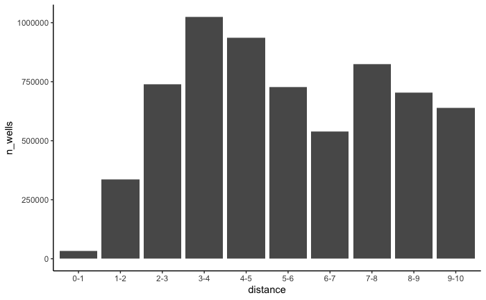

### New + Active wells

#### FE for monitor + air basin-month + year

```
There were 18 warnings (use warnings() to see them)
the matrix is either rank-deficient or indefinitethe matrix is either rank-deficient or indefinite
```

```
Call:
   felm(formula = monthly_mean_co ~ wells_preprod_0to1km + wells_preprod_1to2km +      wells_preprod_2to3km + wells_preprod_3to4km + wells_preprod_4to5km +      wells_preprod_5to6km + wells_preprod_6to7km + wells_preprod_7to8km +      wells_preprod_8to9km + wells_preprod_9to10km + wells_prod_0to1km …

Residuals:
    Min      1Q  Median      3Q     Max
-1.7048 -0.1335 -0.0058  0.1105  4.2276

Coefficients:
                        Estimate Std. Error t value Pr(>|t|)
wells_preprod_0to1km          NA         NA      NA       NA
wells_preprod_1to2km  -3.950e-02  7.578e-02  -0.521 0.602209
wells_preprod_2to3km  -4.116e-02  5.675e-02  -0.725 0.468283
wells_preprod_3to4km   9.755e-02  2.907e-02   3.355 0.000794 ***
wells_preprod_4to5km  -3.161e-01  8.495e-02  -3.721 0.000199 ***
wells_preprod_5to6km  -3.415e-02  6.019e-02  -0.567 0.570396
wells_preprod_6to7km  -1.137e-01  2.375e-02  -4.787 1.70e-06 ***
wells_preprod_7to8km  -1.057e-02  1.971e-02  -0.536 0.591641
wells_preprod_8to9km  -9.576e-03  2.648e-02  -0.362 0.717641
wells_preprod_9to10km -1.642e-02  2.258e-02  -0.727 0.467070
wells_prod_0to1km     -4.616e-02  7.764e-03  -5.945 2.81e-09 ***
wells_prod_1to2km      1.819e-02  2.239e-03   8.125 4.76e-16 ***
wells_prod_2to3km     -6.759e-04  9.314e-04  -0.726 0.468077
wells_prod_3to4km     -7.795e-05  6.170e-04  -0.126 0.899459
wells_prod_4to5km      8.108e-04  6.279e-04   1.291 0.196594
wells_prod_5to6km     -2.629e-03  7.499e-04  -3.506 0.000456 ***
wells_prod_6to7km      5.630e-03  9.120e-04   6.174 6.83e-10 ***
wells_prod_7to8km     -9.642e-04  1.737e-04  -5.552 2.86e-08 ***
wells_prod_8to9km      9.815e-05  4.122e-04   0.238 0.811781
wells_prod_9to10km     1.447e-03  2.920e-04   4.957 7.24e-07 ***
---
Signif. codes:  0 ‘***’ 0.001 ‘**’ 0.01 ‘*’ 0.05 ‘.’ 0.1 ‘ ’ 1

Residual standard error: 0.2649 on 17451 degrees of freedom
  (17 observations deleted due to missingness)
Multiple R-squared(full model): 0.7266   Adjusted R-squared: 0.7214
Multiple R-squared(proj model): 0.01457   Adjusted R-squared: -0.004181
F-statistic(full model):139.7 on 332 and 17451 DF, p-value: < 2.2e-16
F-statistic(proj model): 10.24 on 20 and 17451 DF, p-value: < 2.2e-16
*** Standard errors may be too high due to more than 2 groups and exactDOF=FALSE
```

| distance | new_pt_est | new_ci_lower | new_ci_upper | active_pt_est | active_ci_lower | active_ci_upper |
| --- | --- | --- | --- | --- | --- | --- |
| 0-1 | NaN | NaN | NaN | -4.615918e-02 | -0.0613774288 | -0.0309409397 |
| 1-2 | -0.039499652 | -0.18803763 | 0.10903832 | 1.818893e-02 | 0.0138010569 | 0.0225768091 |
| 2-3 | -0.041160449 | -0.15239651 | 0.07007561 | -6.758687e-04 | -0.0025015593 | 0.0011498219 |
| 3-4 | 0.097553420 | 0.04056559 | 0.15454125 | -7.795041e-05 | -0.0012872497 | 0.0011313489 |
| 4-5 | -0.316078175 | -0.48258414 | -0.14957221 | 8.107787e-04 | -0.0004198627 | 0.0020414200 |
| 5-6 | -0.034154439 | -0.15212552 | 0.08381664 | -2.629190e-03 | -0.0040991710 | -0.0011592089 |
| 6-7 | -0.113703313 | -0.16025694 | -0.06714969 | 5.629910e-03 | 0.0038424023 | 0.0074174187 |
| 7-8 | -0.010572098 | -0.04919940 | 0.02805520 | -9.642444e-04 | -0.0013046590 | -0.0006238298 |
| 8-9 | -0.009576425 | -0.06148398 | 0.04233113 | 9.814527e-05 | -0.0007097014 | 0.0009059919 |
| 9-10 | -0.016424987 | -0.06069268 | 0.02784271 | 1.447465e-03 | 0.0008750780 | 0.0020198514 |

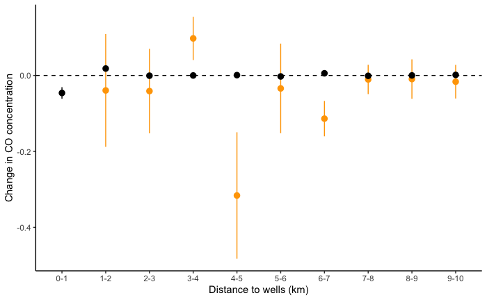

### Indicator for at least one well in the annulus

#### Crude model

```
the matrix is either rank-deficient or indefinitethe matrix is either rank-deficient or indefinite
```

[output not shown]

#### FE for air basin:month + year

```
the matrix is either rank-deficient or indefinitethe matrix is either rank-deficient or indefinite
```

```
Call:
   felm(formula = monthly_mean_co ~ dummy_preprod_0to1km + dummy_preprod_1to2km +      dummy_preprod_2to3km + dummy_preprod_3to4km + dummy_preprod_4to5km +      dummy_preprod_5to6km + dummy_preprod_6to7km + dummy_preprod_7to8km +      dummy_preprod_8to9km + dummy_preprod_9to10km | factor(carb_basin)…

Residuals:
    Min      1Q  Median      3Q     Max
-1.4033 -0.1616  0.0002  0.1305  5.2882

Coefficients:
                       Estimate Std. Error t value Pr(>|t|)
dummy_preprod_0to1km         NA         NA      NA       NA
dummy_preprod_1to2km  -0.106259   0.091818  -1.157   0.2472
dummy_preprod_2to3km   0.338802   0.104603   3.239   0.0012 **
dummy_preprod_3to4km   0.265634   0.066694   3.983 6.84e-05 ***
dummy_preprod_4to5km  -0.216789   0.105651  -2.052   0.0402 *
dummy_preprod_5to6km  -0.029148   0.074659  -0.390   0.6962
dummy_preprod_6to7km  -0.009641   0.071483  -0.135   0.8927
dummy_preprod_7to8km  -0.037412   0.047041  -0.795   0.4264
dummy_preprod_8to9km   0.083866   0.044769   1.873   0.0610 .
dummy_preprod_9to10km -0.151688   0.062187  -2.439   0.0147 *
---
Signif. codes:  0 ‘***’ 0.001 ‘**’ 0.01 ‘*’ 0.05 ‘.’ 0.1 ‘ ’ 1

Residual standard error: 0.3291 on 17599 degrees of freedom
  (17 observations deleted due to missingness)
Multiple R-squared(full model): 0.5744   Adjusted R-squared:  0.57
Multiple R-squared(proj model): 0.002135   Adjusted R-squared: -0.008298
F-statistic(full model):129.1 on 184 and 17599 DF, p-value: < 2.2e-16
F-statistic(proj model): 3.765 on 10 and 17599 DF, p-value: 4.415e-05
```

#### FE for monitor + air basin-month + year

```
the matrix is either rank-deficient or indefinitethe matrix is either rank-deficient or indefinite
```

```
Call:
   felm(formula = monthly_mean_co ~ dummy_preprod_0to1km + dummy_preprod_1to2km +      dummy_preprod_2to3km + dummy_preprod_3to4km + dummy_preprod_4to5km +      dummy_preprod_5to6km + dummy_preprod_6to7km + dummy_preprod_7to8km +      dummy_preprod_8to9km + dummy_preprod_9to10km | factor(site_id) + …

Residuals:
    Min      1Q  Median      3Q     Max
-1.4661 -0.1350 -0.0066  0.1122  4.2553

Coefficients:
                       Estimate Std. Error t value Pr(>|t|)
dummy_preprod_0to1km         NA         NA      NA       NA
dummy_preprod_1to2km  -0.112302   0.075151  -1.494  0.13510
dummy_preprod_2to3km  -0.006156   0.088540  -0.070  0.94457
dummy_preprod_3to4km   0.279646   0.056485   4.951 7.46e-07 ***
dummy_preprod_4to5km  -0.234156   0.085987  -2.723  0.00647 **
dummy_preprod_5to6km  -0.073788   0.060838  -1.213  0.22520
dummy_preprod_6to7km  -0.096982   0.058411  -1.660  0.09687 .
dummy_preprod_7to8km  -0.056064   0.039372  -1.424  0.15448
dummy_preprod_8to9km  -0.009553   0.037210  -0.257  0.79739
dummy_preprod_9to10km -0.089444   0.051303  -1.743  0.08127 .
---
Signif. codes:  0 ‘***’ 0.001 ‘**’ 0.01 ‘*’ 0.05 ‘.’ 0.1 ‘ ’ 1

Residual standard error: 0.2665 on 17461 degrees of freedom
  (17 observations deleted due to missingness)
Multiple R-squared(full model): 0.7232   Adjusted R-squared: 0.7181
Multiple R-squared(proj model): 0.002489   Adjusted R-squared: -0.01591
F-statistic(full model):141.7 on 322 and 17461 DF, p-value: < 2.2e-16
F-statistic(proj model): 4.357 on 10 and 17461 DF, p-value: 4.009e-06
*** Standard errors may be too high due to more than 2 groups and exactDOF=FALSE
```

| distance | pt_est | ci_lower | ci_upper | n_wells |
| --- | --- | --- | --- | --- |
| 0-1 | NaN | NaN | NaN | 34463 |
| 1-2 | -0.112301731 | -0.25960491 | 0.03500145 | 335459 |
| 2-3 | -0.006155517 | -0.17970243 | 0.16739140 | 739569 |
| 3-4 | 0.279645787 | 0.16893033 | 0.39036125 | 1025257 |
| 4-5 | -0.234156497 | -0.40270027 | -0.06561273 | 937142 |
| 5-6 | -0.073788088 | -0.19303656 | 0.04546039 | 726407 |
| 6-7 | -0.096981893 | -0.21147391 | 0.01751013 | 538215 |
| 7-8 | -0.056063508 | -0.13323639 | 0.02110938 | 823666 |
| 8-9 | -0.009553031 | -0.08248913 | 0.06338307 | 704520 |
| 9-10 | -0.089444365 | -0.19000393 | 0.01111520 | 639831 |

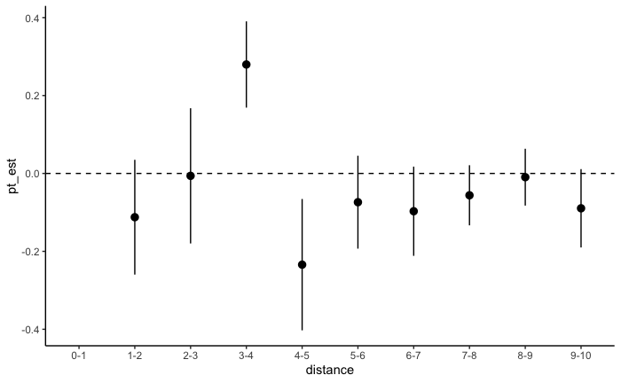

## Pollutant: NO2

**Notes:**

- We used data from 164 monitors and 24052 monitor-months, from 1999-01-01 to 2019-12-01
- We droppped the 2 monitor-months that had nonsensical mean monthly NO2 concentrations of ≤ 0 µg/m^3,

#### Crude model

```
Call:
   felm(formula = monthly_mean_no2 ~ wells_prod_0to1km + wells_prod_1to2km +      wells_prod_2to3km + wells_prod_3to4km + wells_prod_4to5km +      wells_prod_5to6km + wells_prod_6to7km + wells_prod_7to8km +      wells_prod_8to9km + wells_prod_9to10km, data = subset(aqs_exposure_monthly_annuli_prod, …

Residuals:
    Min      1Q  Median      3Q     Max
-35.390  -9.643  -1.329   7.930  75.542

Coefficients:
                    Estimate Std. Error t value Pr(>|t|)
(Intercept)        23.941453   0.083367 287.183  < 2e-16 ***
wells_prod_0to1km  -0.237873   0.038317  -6.208 5.45e-10 ***
wells_prod_1to2km   0.013660   0.016961   0.805   0.4206
wells_prod_2to3km   0.007430   0.010400   0.714   0.4749
wells_prod_3to4km  -0.013610   0.007458  -1.825   0.0680 .
wells_prod_4to5km   0.043929   0.005739   7.655 2.01e-14 ***
wells_prod_5to6km  -0.051214   0.006953  -7.366 1.81e-13 ***
wells_prod_6to7km  -0.050205   0.005213  -9.630  < 2e-16 ***
wells_prod_7to8km   0.004574   0.002321   1.971   0.0487 *
wells_prod_8to9km   0.051119   0.005352   9.551  < 2e-16 ***
wells_prod_9to10km  0.035228   0.004459   7.900 2.90e-15 ***
---
Signif. codes:  0 ‘***’ 0.001 ‘**’ 0.01 ‘*’ 0.05 ‘.’ 0.1 ‘ ’ 1

Residual standard error: 12.93 on 26447 degrees of freedom
Multiple R-squared(full model): 0.04452   Adjusted R-squared: 0.04416
Multiple R-squared(proj model): 0.04452   Adjusted R-squared: 0.04416
F-statistic(full model):123.2 on 10 and 26447 DF, p-value: < 2.2e-16
F-statistic(proj model): 123.2 on 10 and 26447 DF, p-value: < 2.2e-16
```

#### FE for air basin:month + year

```
Call:
   felm(formula = monthly_mean_no2 ~ wells_prod_0to1km + wells_prod_1to2km +      wells_prod_2to3km + wells_prod_3to4km + wells_prod_4to5km +      wells_prod_5to6km + wells_prod_6to7km + wells_prod_7to8km +      wells_prod_8to9km + wells_prod_9to10km | factor(carb_basin):factor(month(month_year)) + …

Residuals:
    Min      1Q  Median      3Q     Max
-43.308  -4.664  -0.178   4.544  47.348

Coefficients:
                    Estimate Std. Error t value Pr(>|t|)
wells_prod_0to1km   0.149306   0.023226   6.428 1.31e-10 ***
wells_prod_1to2km  -0.101263   0.010287  -9.844  < 2e-16 ***
wells_prod_2to3km   0.069840   0.006264  11.149  < 2e-16 ***
wells_prod_3to4km  -0.027060   0.004481  -6.038 1.58e-09 ***
wells_prod_4to5km   0.001082   0.003465   0.312    0.755
wells_prod_5to6km  -0.001871   0.004219  -0.443    0.657
wells_prod_6to7km   0.022213   0.003203   6.936 4.13e-12 ***
wells_prod_7to8km   0.001810   0.001407   1.287    0.198
wells_prod_8to9km  -0.028245   0.003277  -8.619  < 2e-16 ***
wells_prod_9to10km  0.016997   0.002694   6.310 2.83e-10 ***
---
Signif. codes:  0 ‘***’ 0.001 ‘**’ 0.01 ‘*’ 0.05 ‘.’ 0.1 ‘ ’ 1

Residual standard error: 7.748 on 26267 degrees of freedom
  (18 observations deleted due to missingness)
Multiple R-squared(full model): 0.6593   Adjusted R-squared: 0.6571
Multiple R-squared(proj model): 0.02013   Adjusted R-squared: 0.01372
F-statistic(full model):295.5 on 172 and 26267 DF, p-value: < 2.2e-16
F-statistic(proj model): 53.97 on 10 and 26267 DF, p-value: < 2.2e-16
```

#### FE for monitor + air basin-month + year

```
Call:
   felm(formula = monthly_mean_no2 ~ wells_prod_0to1km + wells_prod_1to2km +      wells_prod_2to3km + wells_prod_3to4km + wells_prod_4to5km +      wells_prod_5to6km + wells_prod_6to7km + wells_prod_7to8km +      wells_prod_8to9km + wells_prod_9to10km | factor(site_id) +      factor(carb_basin):facto…

Residuals:
    Min      1Q  Median      3Q     Max
-38.174  -3.125  -0.258   2.670  37.738

Coefficients:
                     Estimate Std. Error t value Pr(>|t|)
wells_prod_0to1km   0.0808506  0.2028819   0.399 0.690259
wells_prod_1to2km   0.1703573  0.0472658   3.604 0.000314 ***
wells_prod_2to3km   0.0300369  0.0209298   1.435 0.151270
wells_prod_3to4km   0.0521190  0.0128876   4.044 5.28e-05 ***
wells_prod_4to5km   0.0296622  0.0126029   2.354 0.018605 *
wells_prod_5to6km  -0.1242004  0.0150382  -8.259  < 2e-16 ***
wells_prod_6to7km   0.1713816  0.0192695   8.894  < 2e-16 ***
wells_prod_7to8km   0.0005739  0.0037097   0.155 0.877068
wells_prod_8to9km  -0.0341517  0.0096423  -3.542 0.000398 ***
wells_prod_9to10km  0.0260265  0.0059156   4.400 1.09e-05 ***
---
Signif. codes:  0 ‘***’ 0.001 ‘**’ 0.01 ‘*’ 0.05 ‘.’ 0.1 ‘ ’ 1

Residual standard error: 5.18 on 15871 degrees of freedom
  (17 observations deleted due to missingness)
Multiple R-squared(full model): 0.8569   Adjusted R-squared: 0.8542
Multiple R-squared(proj model): 0.01398   Adjusted R-squared: -0.004414
F-statistic(full model):321.1 on 296 and 15871 DF, p-value: < 2.2e-16
F-statistic(proj model):  22.5 on 10 and 15871 DF, p-value: < 2.2e-16
*** Standard errors may be too high due to more than 2 groups and exactDOF=FALSE

                          2.5 %       97.5 %
wells_prod_0to1km  -0.316820911  0.478522113
wells_prod_1to2km   0.077710959  0.263003660
wells_prod_2to3km  -0.010987827  0.071061577
wells_prod_3to4km   0.026857957  0.077380127
wells_prod_4to5km   0.004959028  0.054365432
wells_prod_5to6km  -0.153676904 -0.094723932
wells_prod_6to7km   0.133611148  0.209152060
wells_prod_7to8km  -0.006697632  0.007845342
wells_prod_8to9km  -0.053051708 -0.015251728
wells_prod_9to10km  0.014431317  0.037621651
```

| distance | pt_est | ci_lower | ci_upper |
| --- | --- | --- | --- |
| 0-1 | 0.0808506010 | -0.316820911 | 0.478522113 |
| 1-2 | 0.1703573093 | 0.077710959 | 0.263003660 |
| 2-3 | 0.0300368751 | -0.010987827 | 0.071061577 |
| 3-4 | 0.0521190420 | 0.026857957 | 0.077380127 |
| 4-5 | 0.0296622298 | 0.004959028 | 0.054365432 |
| 5-6 | -0.1242004176 | -0.153676904 | -0.094723932 |
| 6-7 | 0.1713816040 | 0.133611148 | 0.209152060 |
| 7-8 | 0.0005738552 | -0.006697632 | 0.007845342 |
| 8-9 | -0.0341517178 | -0.053051708 | -0.015251728 |
| 9-10 | 0.0260264840 | 0.014431317 | 0.037621651 |

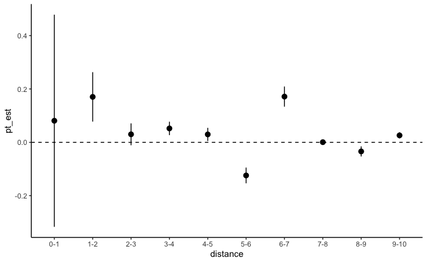

### New + Active wells

#### FE for monitor + air basin-month + year

```
There were 50 or more warnings (use warnings() to see the first 50)
```

```
Call:
   felm(formula = monthly_mean_no2 ~ wells_preprod_0to1km + wells_preprod_1to2km +      wells_preprod_2to3km + wells_preprod_3to4km + wells_preprod_4to5km +      wells_preprod_5to6km + wells_preprod_6to7km + wells_preprod_7to8km +      wells_preprod_8to9km + wells_preprod_9to10km + wells_prod_0to1km…

Residuals:
    Min      1Q  Median      3Q     Max
-40.676  -3.224  -0.252   2.714  45.478

Coefficients:
                       Estimate Std. Error t value Pr(>|t|)
wells_preprod_0to1km   8.501397   7.586553   1.121 0.262474
wells_preprod_1to2km  -1.195979   0.678853  -1.762 0.078121 .
wells_preprod_2to3km   0.330162   0.880359   0.375 0.707640
wells_preprod_3to4km   0.308308   0.338295   0.911 0.362114
wells_preprod_4to5km  -1.631061   0.768567  -2.122 0.033830 *
wells_preprod_5to6km  -0.739723   0.869121  -0.851 0.394712
wells_preprod_6to7km  -0.832067   0.449022  -1.853 0.063884 .
wells_preprod_7to8km   0.750236   0.374674   2.002 0.045255 *
wells_preprod_8to9km  -0.586523   0.518144  -1.132 0.257657
wells_preprod_9to10km  0.243714   0.429424   0.568 0.570354
wells_prod_0to1km      0.063935   0.042753   1.495 0.134809
wells_prod_1to2km     -0.027398   0.020726  -1.322 0.186194
wells_prod_2to3km      0.061865   0.014291   4.329  1.5e-05 ***
wells_prod_3to4km     -0.014990   0.009890  -1.516 0.129616
wells_prod_4to5km      0.004010   0.008682   0.462 0.644209
wells_prod_5to6km     -0.015483   0.010145  -1.526 0.126959
wells_prod_6to7km      0.043729   0.012353   3.540 0.000401 ***
wells_prod_7to8km      0.004830   0.003267   1.478 0.139300
wells_prod_8to9km      0.003229   0.007809   0.414 0.679227
wells_prod_9to10km     0.006788   0.004380   1.550 0.121235
---
Signif. codes:  0 ‘***’ 0.001 ‘**’ 0.01 ‘*’ 0.05 ‘.’ 0.1 ‘ ’ 1

Residual standard error: 5.204 on 26095 degrees of freedom
  (18 observations deleted due to missingness)
Multiple R-squared(full model): 0.8473   Adjusted R-squared: 0.8453
Multiple R-squared(proj model): 0.003528   Adjusted R-squared: -0.009608
F-statistic(full model):421.1 on 344 and 26095 DF, p-value: < 2.2e-16
F-statistic(proj model):  4.62 on 20 and 26095 DF, p-value: 2.967e-11
*** Standard errors may be too high due to more than 2 groups and exactDOF=FALSE
```

| distance | new_pt_est | new_ci_lower | new_ci_upper | active_pt_est | active_ci_lower | active_ci_upper |
| --- | --- | --- | --- | --- | --- | --- |
| 0-1 | 8.5013970 | -6.36866295 | 23.37145702 | 0.063935107 | -0.019863255 | 0.147733470 |
| 1-2 | -1.1959793 | -2.52656882 | 0.13461025 | -0.027398245 | -0.068021403 | 0.013224913 |
| 2-3 | 0.3301619 | -1.39539007 | 2.05571392 | 0.061864977 | 0.033854006 | 0.089875948 |
| 3-4 | 0.3083083 | -0.35476833 | 0.97138490 | -0.014990342 | -0.034375813 | 0.004395129 |
| 4-5 | -1.6310607 | -3.13749498 | -0.12462634 | 0.004009575 | -0.013007581 | 0.021026732 |
| 5-6 | -0.7397234 | -2.44324837 | 0.96380151 | -0.015483401 | -0.035367593 | 0.004400790 |
| 6-7 | -0.8320674 | -1.71217531 | 0.04804044 | 0.043729187 | 0.019515670 | 0.067942703 |
| 7-8 | 0.7502358 | 0.01585368 | 1.48461783 | 0.004830303 | -0.001573480 | 0.011234085 |
| 8-9 | -0.5865232 | -1.60211314 | 0.42906684 | 0.003229104 | -0.012076510 | 0.018534718 |
| 9-10 | 0.2437143 | -0.59798110 | 1.08540976 | 0.006788073 | -0.001797662 | 0.015373809 |

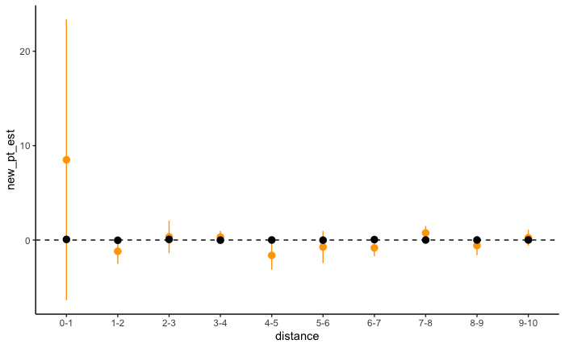

### Indicator for at least one well in the annulus

#### Crude model

```
Call:
   felm(formula = monthly_mean_no2 ~ dummy_preprod_0to1km + dummy_preprod_1to2km +      dummy_preprod_2to3km + dummy_preprod_3to4km + dummy_preprod_4to5km +      dummy_preprod_5to6km + dummy_preprod_6to7km + dummy_preprod_7to8km +      dummy_preprod_8to9km + dummy_preprod_9to10km, data = subset(aqs_…

Residuals:
    Min      1Q  Median      3Q     Max
-30.868  -9.872  -1.250   8.167  74.900

Coefficients:
                      Estimate Std. Error t value Pr(>|t|)
(Intercept)            24.5834     0.0815 301.640  < 2e-16 ***
dummy_preprod_0to1km  -30.8718     8.2773  -3.730 0.000192 ***
dummy_preprod_1to2km    2.8907     3.3155   0.872 0.383291
dummy_preprod_2to3km   20.7223     3.4219   6.056 1.42e-09 ***
dummy_preprod_3to4km    5.4343     1.9781   2.747 0.006015 **
dummy_preprod_4to5km   -3.0137     2.0759  -1.452 0.146583
dummy_preprod_5to6km    6.4180     2.5046   2.563 0.010397 *
dummy_preprod_6to7km    3.4808     2.5717   1.353 0.175912
dummy_preprod_7to8km    9.2408     1.8601   4.968 6.81e-07 ***
dummy_preprod_8to9km    8.3939     1.7537   4.786 1.71e-06 ***
dummy_preprod_9to10km   0.9562     2.1801   0.439 0.660962
---
Signif. codes:  0 ‘***’ 0.001 ‘**’ 0.01 ‘*’ 0.05 ‘.’ 0.1 ‘ ’ 1

Residual standard error: 13.2 on 26447 degrees of freedom
Multiple R-squared(full model): 0.004679   Adjusted R-squared: 0.004303
Multiple R-squared(proj model): 0.004679   Adjusted R-squared: 0.004303
F-statistic(full model):12.43 on 10 and 26447 DF, p-value: < 2.2e-16
F-statistic(proj model): 12.43 on 10 and 26447 DF, p-value: < 2.2e-16
```

#### FE for air basin:month + year

```
Call:
   felm(formula = monthly_mean_no2 ~ dummy_preprod_0to1km + dummy_preprod_1to2km +      dummy_preprod_2to3km + dummy_preprod_3to4km + dummy_preprod_4to5km +      dummy_preprod_5to6km + dummy_preprod_6to7km + dummy_preprod_7to8km +      dummy_preprod_8to9km + dummy_preprod_9to10km | factor(carb_basin…

Residuals:
    Min      1Q  Median      3Q     Max
-39.038  -4.746  -0.209   4.616  47.428

Coefficients:
                      Estimate Std. Error t value Pr(>|t|)
dummy_preprod_0to1km  -15.8784     4.9175  -3.229  0.00124 **
dummy_preprod_1to2km   -3.4429     1.9678  -1.750  0.08019 .
dummy_preprod_2to3km    8.3126     2.0334   4.088 4.36e-05 ***
dummy_preprod_3to4km    1.2912     1.1761   1.098  0.27227
dummy_preprod_4to5km   -0.4534     1.2336  -0.368  0.71320
dummy_preprod_5to6km    1.0124     1.4868   0.681  0.49594
dummy_preprod_6to7km    1.2195     1.5271   0.799  0.42454
dummy_preprod_7to8km    2.7337     1.1061   2.471  0.01346 *
dummy_preprod_8to9km    1.1653     1.0446   1.116  0.26461
dummy_preprod_9to10km   0.7456     1.2955   0.576  0.56494
---
Signif. codes:  0 ‘***’ 0.001 ‘**’ 0.01 ‘*’ 0.05 ‘.’ 0.1 ‘ ’ 1

Residual standard error: 7.822 on 26267 degrees of freedom
  (18 observations deleted due to missingness)
Multiple R-squared(full model): 0.6528   Adjusted R-squared: 0.6505
Multiple R-squared(proj model): 0.00139   Adjusted R-squared: -0.00515
F-statistic(full model):287.1 on 172 and 26267 DF, p-value: < 2.2e-16
F-statistic(proj model): 3.655 on 10 and 26267 DF, p-value: 6.825e-05
```

#### FE for monitor + air basin-month + year

```
Call:
   felm(formula = monthly_mean_no2 ~ dummy_preprod_0to1km + dummy_preprod_1to2km +      dummy_preprod_2to3km + dummy_preprod_3to4km + dummy_preprod_4to5km +      dummy_preprod_5to6km + dummy_preprod_6to7km + dummy_preprod_7to8km +      dummy_preprod_8to9km + dummy_preprod_9to10km | factor(site_id) +…

Residuals:
    Min      1Q  Median      3Q     Max
-42.111  -3.222  -0.261   2.708  45.446

Coefficients:
                      Estimate Std. Error t value Pr(>|t|)
dummy_preprod_0to1km   -4.1385     3.3290  -1.243   0.2138
dummy_preprod_1to2km   -2.9304     1.3246  -2.212   0.0270 *
dummy_preprod_2to3km    1.5715     1.3979   1.124   0.2609
dummy_preprod_3to4km    2.1042     0.8124   2.590   0.0096 **
dummy_preprod_4to5km   -1.8323     0.8650  -2.118   0.0342 *
dummy_preprod_5to6km   -0.5243     1.0026  -0.523   0.6010
dummy_preprod_6to7km   -1.2974     1.0258  -1.265   0.2060
dummy_preprod_7to8km    0.8989     0.7610   1.181   0.2375
dummy_preprod_8to9km   -0.7121     0.7142  -0.997   0.3187
dummy_preprod_9to10km  -0.5285     0.8767  -0.603   0.5467
---
Signif. codes:  0 ‘***’ 0.001 ‘**’ 0.01 ‘*’ 0.05 ‘.’ 0.1 ‘ ’ 1

Residual standard error: 5.21 on 26105 degrees of freedom
  (18 observations deleted due to missingness)
Multiple R-squared(full model): 0.8469   Adjusted R-squared: 0.845
Multiple R-squared(proj model): 0.0009133   Adjusted R-squared: -0.01187
F-statistic(full model):432.5 on 334 and 26105 DF, p-value: < 2.2e-16
F-statistic(proj model): 2.386 on 10 and 26105 DF, p-value: 0.007994
*** Standard errors may be too high due to more than 2 groups and exactDOF=FALSE

                            2.5 %     97.5 %
dummy_preprod_0to1km  -10.6634457  2.3864493
dummy_preprod_1to2km   -5.5266804 -0.3340279
dummy_preprod_2to3km   -1.1683608  4.3113721
dummy_preprod_3to4km    0.5119048  3.6964929
dummy_preprod_4to5km   -3.5277920 -0.1368919
dummy_preprod_5to6km   -2.4895500  1.4409479
dummy_preprod_6to7km   -3.3078929  0.7131690
dummy_preprod_7to8km   -0.5926217  2.3905150
dummy_preprod_8to9km   -2.1118643  0.6877274
dummy_preprod_9to10km  -2.2469279  1.1899513
```

| distance | pt_est | ci_lower | ci_upper |
| --- | --- | --- | --- |
| 0-1 | -4.1384982 | -10.6634457 | 2.3864493 |
| 1-2 | -2.9303541 | -5.5266804 | -0.3340279 |
| 2-3 | 1.5715057 | -1.1683608 | 4.3113721 |
| 3-4 | 2.1041988 | 0.5119048 | 3.6964929 |
| 4-5 | -1.8323420 | -3.5277920 | -0.1368919 |
| 5-6 | -0.5243010 | -2.4895500 | 1.4409479 |
| 6-7 | -1.2973620 | -3.3078929 | 0.7131690 |
| 7-8 | 0.8989467 | -0.5926217 | 2.3905150 |
| 8-9 | -0.7120685 | -2.1118643 | 0.6877274 |
| 9-10 | -0.5284883 | -2.2469279 | 1.1899513 |

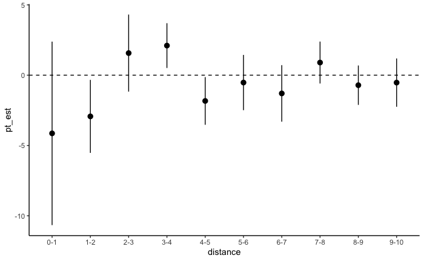

## Pollutant: O3

**Notes:**

- We used data from 284 monitors and 43161 monitor-months, from 1999-01-01 to 2019-12-01
- We droppped the 0 monitor-months that had nonsensical mean monthly O3 concentrations of ≤ 0 µg/m^3,

#### Crude model

```
Call:
   felm(formula = monthly_mean_ozone ~ wells_prod_0to1km + wells_prod_1to2km +      wells_prod_2to3km + wells_prod_3to4km + wells_prod_4to5km +      wells_prod_5to6km + wells_prod_6to7km + wells_prod_7to8km +      wells_prod_8to9km + wells_prod_9to10km, data = subset(aqs_exposure_monthly_annuli_prod…

Residuals:
      Min        1Q    Median        3Q       Max
-0.045419 -0.009587 -0.001004  0.008508  0.056659

Coefficients:
                     Estimate Std. Error t value Pr(>|t|)
(Intercept)         4.323e-02  6.678e-05 647.364  < 2e-16 ***
wells_prod_0to1km   4.062e-05  3.069e-05   1.324  0.18558
wells_prod_1to2km  -2.959e-05  9.193e-06  -3.218  0.00129 **
wells_prod_2to3km  -4.545e-06  6.704e-06  -0.678  0.49781
wells_prod_3to4km   2.032e-05  4.274e-06   4.755 1.99e-06 ***
wells_prod_4to5km  -1.155e-05  4.609e-06  -2.506  0.01223 *
wells_prod_5to6km   1.637e-05  6.656e-06   2.460  0.01390 *
wells_prod_6to7km  -8.528e-06  5.069e-06  -1.682  0.09251 .
wells_prod_7to8km  -1.095e-05  2.107e-06  -5.199 2.01e-07 ***
wells_prod_8to9km   1.500e-05  4.564e-06   3.288  0.00101 **
wells_prod_9to10km -3.600e-06  3.680e-06  -0.978  0.32796
---
Signif. codes:  0 ‘***’ 0.001 ‘**’ 0.01 ‘*’ 0.05 ‘.’ 0.1 ‘ ’ 1

Residual standard error: 0.01376 on 45760 degrees of freedom
Multiple R-squared(full model): 0.006064   Adjusted R-squared: 0.005847
Multiple R-squared(proj model): 0.006064   Adjusted R-squared: 0.005847
F-statistic(full model):27.92 on 10 and 45760 DF, p-value: < 2.2e-16
F-statistic(proj model): 27.92 on 10 and 45760 DF, p-value: < 2.2e-16
```

#### FE for air basin:month + year

```
Call:
   felm(formula = monthly_mean_ozone ~ wells_prod_0to1km + wells_prod_1to2km +      wells_prod_2to3km + wells_prod_3to4km + wells_prod_4to5km +      wells_prod_5to6km + wells_prod_6to7km + wells_prod_7to8km +      wells_prod_8to9km + wells_prod_9to10km | factor(carb_basin):factor(month(month_year)) …

Residuals:
      Min        1Q    Median        3Q       Max
-0.064204 -0.004421 -0.000077  0.004271  0.040195

Coefficients:
                     Estimate Std. Error t value Pr(>|t|)
wells_prod_0to1km  -4.972e-05  1.697e-05  -2.929 0.003399 **
wells_prod_1to2km   4.730e-06  5.087e-06   0.930 0.352517
wells_prod_2to3km  -1.236e-05  3.699e-06  -3.342 0.000831 ***
wells_prod_3to4km   1.873e-05  2.365e-06   7.922 2.39e-15 ***
wells_prod_4to5km  -2.750e-05  2.567e-06 -10.711  < 2e-16 ***
wells_prod_5to6km   3.329e-05  3.702e-06   8.992  < 2e-16 ***
wells_prod_6to7km  -6.476e-06  2.840e-06  -2.281 0.022580 *
wells_prod_7to8km  -1.444e-05  1.168e-06 -12.360  < 2e-16 ***
wells_prod_8to9km   6.527e-06  2.535e-06   2.574 0.010046 *
wells_prod_9to10km -4.949e-06  2.041e-06  -2.424 0.015348 *
---
Signif. codes:  0 ‘***’ 0.001 ‘**’ 0.01 ‘*’ 0.05 ‘.’ 0.1 ‘ ’ 1

Residual standard error: 0.007573 on 45543 degrees of freedom
  (18 observations deleted due to missingness)
Multiple R-squared(full model): 0.7003   Adjusted R-squared: 0.6989
Multiple R-squared(proj model): 0.01387   Adjusted R-squared: 0.009346
F-statistic(full model):509.1 on 209 and 45543 DF, p-value: < 2.2e-16
F-statistic(proj model): 64.06 on 10 and 45543 DF, p-value: < 2.2e-16
```

#### FE for monitor + air basin-month + year

```
Call:
   felm(formula = monthly_mean_ozone ~ wells_prod_0to1km + wells_prod_1to2km +      wells_prod_2to3km + wells_prod_3to4km + wells_prod_4to5km +      wells_prod_5to6km + wells_prod_6to7km + wells_prod_7to8km +      wells_prod_8to9km + wells_prod_9to10km | factor(site_id) +      factor(carb_basin):fac…

Residuals:
      Min        1Q    Median        3Q       Max
-0.061525 -0.003451 -0.000030  0.003402  0.036569

Coefficients:
                     Estimate Std. Error t value Pr(>|t|)
wells_prod_0to1km  -5.340e-05  2.105e-05  -2.536  0.01120 *
wells_prod_1to2km   1.411e-05  6.557e-06   2.152  0.03137 *
wells_prod_2to3km  -3.638e-06  5.068e-06  -0.718  0.47293
wells_prod_3to4km   8.179e-06  4.412e-06   1.854  0.06380 .
wells_prod_4to5km  -2.608e-05  5.028e-06  -5.187 2.15e-07 ***
wells_prod_5to6km   2.936e-05  6.192e-06   4.742 2.12e-06 ***
wells_prod_6to7km  -1.873e-05  5.421e-06  -3.455  0.00055 ***
wells_prod_7to8km  -2.902e-06  2.527e-06  -1.148  0.25079
wells_prod_8to9km   3.487e-06  4.953e-06   0.704  0.48152
wells_prod_9to10km -4.115e-06  3.504e-06  -1.174  0.24022
---
Signif. codes:  0 ‘***’ 0.001 ‘**’ 0.01 ‘*’ 0.05 ‘.’ 0.1 ‘ ’ 1

Residual standard error: 0.005771 on 45261 degrees of freedom
  (18 observations deleted due to missingness)
Multiple R-squared(full model): 0.827   Adjusted R-squared: 0.8251
Multiple R-squared(proj model): 0.0009645   Adjusted R-squared: -0.009873
F-statistic(full model):440.7 on 491 and 45261 DF, p-value: < 2.2e-16
F-statistic(proj model): 4.369 on 10 and 45261 DF, p-value: 3.761e-06
*** Standard errors may be too high due to more than 2 groups and exactDOF=FALSE

                           2.5 %        97.5 %
wells_prod_0to1km  -9.466441e-05 -1.213554e-05
wells_prod_1to2km   1.261529e-06  2.696426e-05
wells_prod_2to3km  -1.357187e-05  6.296381e-06
wells_prod_3to4km  -4.695515e-07  1.682722e-05
wells_prod_4to5km  -3.593193e-05 -1.622341e-05
wells_prod_5to6km   1.722640e-05  4.149732e-05
wells_prod_6to7km  -2.935469e-05 -8.105033e-06
wells_prod_7to8km  -7.855646e-06  2.050968e-06
wells_prod_8to9km  -6.222111e-06  1.319512e-05
wells_prod_9to10km -1.098326e-05  2.752588e-06
```

| distance | pt_est | ci_lower | ci_upper |
| --- | --- | --- | --- |
| 0-1 | -5.339998e-05 | -9.466441e-05 | -1.213554e-05 |
| 1-2 | 1.411290e-05 | 1.261529e-06 | 2.696426e-05 |
| 2-3 | -3.637742e-06 | -1.357187e-05 | 6.296381e-06 |
| 3-4 | 8.178833e-06 | -4.695515e-07 | 1.682722e-05 |
| 4-5 | -2.607767e-05 | -3.593193e-05 | -1.622341e-05 |
| 5-6 | 2.936186e-05 | 1.722640e-05 | 4.149732e-05 |
| 6-7 | -1.872986e-05 | -2.935469e-05 | -8.105033e-06 |
| 7-8 | -2.902339e-06 | -7.855646e-06 | 2.050968e-06 |
| 8-9 | 3.486505e-06 | -6.222111e-06 | 1.319512e-05 |
| 9-10 | -4.115336e-06 | -1.098326e-05 | 2.752588e-06 |

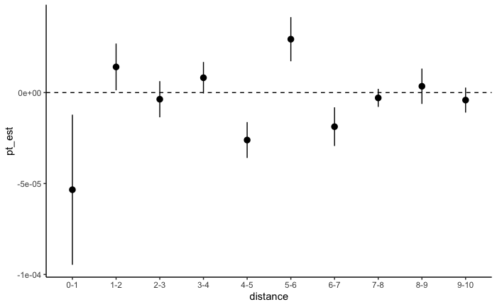

### New + Active wells

#### FE for monitor + air basin-month + year

```
Call:
   felm(formula = monthly_mean_ozone ~ wells_preprod_0to1km + wells_preprod_1to2km +      wells_preprod_2to3km + wells_preprod_3to4km + wells_preprod_4to5km +      wells_preprod_5to6km + wells_preprod_6to7km + wells_preprod_7to8km +      wells_preprod_8to9km + wells_preprod_9to10km + wells_prod_0to1…

Residuals:
      Min        1Q    Median        3Q       Max
-0.061434 -0.003450 -0.000028  0.003402  0.036565

Coefficients:
                        Estimate Std. Error t value Pr(>|t|)
wells_preprod_0to1km   1.278e-03  9.719e-04   1.315 0.188452
wells_preprod_1to2km  -3.249e-04  3.695e-04  -0.879 0.379175
wells_preprod_2to3km  -1.046e-03  4.971e-04  -2.104 0.035347 *
wells_preprod_3to4km  -2.182e-04  2.702e-04  -0.807 0.419445
wells_preprod_4to5km  -2.398e-04  4.646e-04  -0.516 0.605678
wells_preprod_5to6km   3.907e-04  3.641e-04   1.073 0.283304
wells_preprod_6to7km  -3.246e-04  2.467e-04  -1.316 0.188313
wells_preprod_7to8km   7.976e-04  3.523e-04   2.264 0.023567 *
wells_preprod_8to9km   1.144e-03  4.002e-04   2.858 0.004264 **
wells_preprod_9to10km -5.450e-04  4.188e-04  -1.301 0.193103
wells_prod_0to1km     -4.651e-05  2.190e-05  -2.124 0.033693 *
wells_prod_1to2km      1.338e-05  6.663e-06   2.009 0.044569 *
wells_prod_2to3km     -4.045e-06  5.110e-06  -0.792 0.428582
wells_prod_3to4km      8.312e-06  4.428e-06   1.877 0.060500 .
wells_prod_4to5km     -2.554e-05  5.050e-06  -5.058 4.26e-07 ***
wells_prod_5to6km      2.937e-05  6.213e-06   4.727 2.28e-06 ***
wells_prod_6to7km     -1.866e-05  5.487e-06  -3.400 0.000674 ***
wells_prod_7to8km     -2.897e-06  2.531e-06  -1.145 0.252368
wells_prod_8to9km      2.783e-06  4.973e-06   0.559 0.575843
wells_prod_9to10km    -3.953e-06  3.536e-06  -1.118 0.263565
---
Signif. codes:  0 ‘***’ 0.001 ‘**’ 0.01 ‘*’ 0.05 ‘.’ 0.1 ‘ ’ 1

Residual standard error: 0.00577 on 45251 degrees of freedom
  (18 observations deleted due to missingness)
Multiple R-squared(full model): 0.8271   Adjusted R-squared: 0.8252
Multiple R-squared(proj model): 0.001574   Adjusted R-squared: -0.00948
F-statistic(full model):432.1 on 501 and 45251 DF, p-value: < 2.2e-16
F-statistic(proj model): 3.566 on 20 and 45251 DF, p-value: 1.121e-07
*** Standard errors may be too high due to more than 2 groups and exactDOF=FALSE
```

| distance | new_pt_est | new_ci_lower | new_ci_upper | active_pt_est | active_ci_lower | active_ci_upper |
| --- | --- | --- | --- | --- | --- | --- |
| 0-1 | 0.0012781913 | -0.0006266834 | 3.183066e-03 | -4.651110e-05 | -8.943554e-05 | -3.586657e-06 |
| 1-2 | -0.0003249339 | -0.0010491292 | 3.992615e-04 | 1.338507e-05 | 3.247756e-07 | 2.644537e-05 |
| 2-3 | -0.0010461198 | -0.0020204516 | -7.178798e-05 | -4.044869e-06 | -1.405969e-05 | 5.969955e-06 |
| 3-4 | -0.0002181654 | -0.0007477813 | 3.114505e-04 | 8.312250e-06 | -3.668023e-07 | 1.699130e-05 |
| 4-5 | -0.0002398330 | -0.0011503823 | 6.707163e-04 | -2.554306e-05 | -3.544199e-05 | -1.564414e-05 |
| 5-6 | 0.0003906885 | -0.0003230104 | 1.104387e-03 | 2.937117e-05 | 1.719314e-05 | 4.154920e-05 |
| 6-7 | -0.0003246234 | -0.0008082538 | 1.590070e-04 | -1.865510e-05 | -2.940902e-05 | -7.901176e-06 |
| 7-8 | 0.0007976212 | 0.0001071524 | 1.488090e-03 | -2.896651e-06 | -7.856752e-06 | 2.063451e-06 |
| 8-9 | 0.0011437167 | 0.0003593736 | 1.928060e-03 | 2.782506e-06 | -6.965543e-06 | 1.253055e-05 |
| 9-10 | -0.0005450224 | -0.0013658251 | 2.757804e-04 | -3.952843e-06 | -1.088264e-05 | 2.976951e-06 |

```
There were 18 warnings (use warnings() to see them)
```

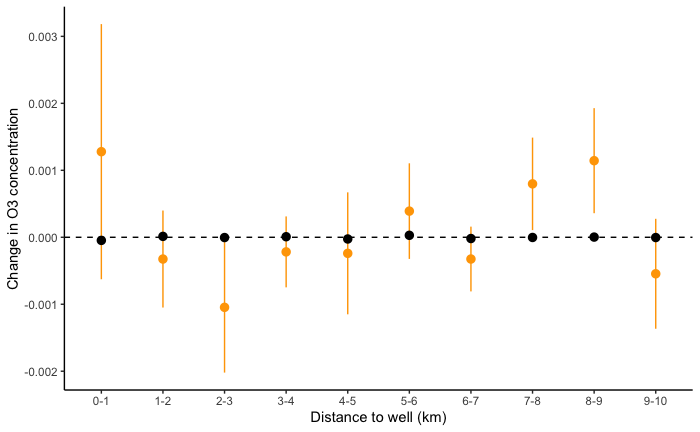

### Indicator for at least one well in the annulus

#### Crude model

```
Call:
   felm(formula = monthly_mean_ozone ~ dummy_preprod_0to1km + dummy_preprod_1to2km +      dummy_preprod_2to3km + dummy_preprod_3to4km + dummy_preprod_4to5km +      dummy_preprod_5to6km + dummy_preprod_6to7km + dummy_preprod_7to8km +      dummy_preprod_8to9km + dummy_preprod_9to10km, data = subset(aq…

Residuals:
      Min        1Q    Median        3Q       Max
-0.042987 -0.009621 -0.001061  0.008507  0.056646

Coefficients:
                        Estimate Std. Error t value Pr(>|t|)
(Intercept)            4.332e-02  6.479e-05 668.618  < 2e-16 ***
dummy_preprod_0to1km   1.639e-02  4.919e-03   3.333 0.000861 ***
dummy_preprod_1to2km  -1.900e-03  2.035e-03  -0.934 0.350399
dummy_preprod_2to3km   3.065e-04  1.763e-03   0.174 0.861962
dummy_preprod_3to4km   4.162e-03  1.368e-03   3.043 0.002340 **
dummy_preprod_4to5km  -2.037e-03  1.536e-03  -1.326 0.184863
dummy_preprod_5to6km   1.666e-03  1.560e-03   1.068 0.285575
dummy_preprod_6to7km   9.200e-04  1.747e-03   0.527 0.598505
dummy_preprod_7to8km   2.194e-04  1.408e-03   0.156 0.876194
dummy_preprod_8to9km  -1.587e-03  1.470e-03  -1.080 0.280290
dummy_preprod_9to10km  1.131e-03  1.968e-03   0.575 0.565468
---
Signif. codes:  0 ‘***’ 0.001 ‘**’ 0.01 ‘*’ 0.05 ‘.’ 0.1 ‘ ’ 1

Residual standard error: 0.0138 on 45760 degrees of freedom
Multiple R-squared(full model): 0.000639   Adjusted R-squared: 0.0004206
Multiple R-squared(proj model): 0.000639   Adjusted R-squared: 0.0004206
F-statistic(full model):2.926 on 10 and 45760 DF, p-value: 0.001135
F-statistic(proj model): 2.926 on 10 and 45760 DF, p-value: 0.001135
```

#### FE for air basin:month + year

```
Call:
   felm(formula = monthly_mean_ozone ~ dummy_preprod_0to1km + dummy_preprod_1to2km +      dummy_preprod_2to3km + dummy_preprod_3to4km + dummy_preprod_4to5km +      dummy_preprod_5to6km + dummy_preprod_6to7km + dummy_preprod_7to8km +      dummy_preprod_8to9km + dummy_preprod_9to10km | factor(carb_bas…

Residuals:
      Min        1Q    Median        3Q       Max
-0.058740 -0.004421 -0.000068  0.004280  0.040783

Coefficients:
                        Estimate Std. Error t value Pr(>|t|)
dummy_preprod_0to1km   6.119e-03  2.722e-03   2.248  0.02456 *
dummy_preprod_1to2km  -1.426e-03  1.126e-03  -1.266  0.20551
dummy_preprod_2to3km  -1.736e-03  9.762e-04  -1.778  0.07533 .
dummy_preprod_3to4km  -1.756e-04  7.576e-04  -0.232  0.81673
dummy_preprod_4to5km   1.482e-05  8.504e-04   0.017  0.98610
dummy_preprod_5to6km   8.947e-04  8.634e-04   1.036  0.30008
dummy_preprod_6to7km  -2.730e-03  9.673e-04  -2.822  0.00477 **
dummy_preprod_7to8km  -8.350e-04  7.801e-04  -1.070  0.28447
dummy_preprod_8to9km  -2.145e-03  8.150e-04  -2.632  0.00850 **
dummy_preprod_9to10km -6.637e-04  1.089e-03  -0.610  0.54213
---
Signif. codes:  0 ‘***’ 0.001 ‘**’ 0.01 ‘*’ 0.05 ‘.’ 0.1 ‘ ’ 1

Residual standard error: 0.007623 on 45543 degrees of freedom
  (18 observations deleted due to missingness)
Multiple R-squared(full model): 0.6962   Adjusted R-squared: 0.6949
Multiple R-squared(proj model): 0.0006574   Adjusted R-squared: -0.003929
F-statistic(full model):499.5 on 209 and 45543 DF, p-value: < 2.2e-16
F-statistic(proj model): 2.996 on 10 and 45543 DF, p-value: 0.0008727
```

#### FE for monitor + air basin-month + year

```
Call:
   felm(formula = monthly_mean_ozone ~ dummy_preprod_0to1km + dummy_preprod_1to2km +      dummy_preprod_2to3km + dummy_preprod_3to4km + dummy_preprod_4to5km +      dummy_preprod_5to6km + dummy_preprod_6to7km + dummy_preprod_7to8km +      dummy_preprod_8to9km + dummy_preprod_9to10km | factor(site_id)…

Residuals:
      Min        1Q    Median        3Q       Max
-0.060889 -0.003452 -0.000028  0.003406  0.036567

Coefficients:
                        Estimate Std. Error t value Pr(>|t|)
dummy_preprod_0to1km   0.0039512  0.0020678   1.911  0.05604 .
dummy_preprod_1to2km  -0.0011329  0.0008777  -1.291  0.19678
dummy_preprod_2to3km  -0.0020651  0.0007565  -2.730  0.00634 **
dummy_preprod_3to4km  -0.0002961  0.0005903  -0.502  0.61589
dummy_preprod_4to5km  -0.0008235  0.0006626  -1.243  0.21395
dummy_preprod_5to6km   0.0002088  0.0006679   0.313  0.75457
dummy_preprod_6to7km  -0.0013263  0.0007420  -1.788  0.07386 .
dummy_preprod_7to8km   0.0014271  0.0006131   2.328  0.01993 *
dummy_preprod_8to9km   0.0010136  0.0006316   1.605  0.10850
dummy_preprod_9to10km -0.0007485  0.0008383  -0.893  0.37194
---
Signif. codes:  0 ‘***’ 0.001 ‘**’ 0.01 ‘*’ 0.05 ‘.’ 0.1 ‘ ’ 1

Residual standard error: 0.005772 on 45261 degrees of freedom
  (18 observations deleted due to missingness)
Multiple R-squared(full model): 0.8269   Adjusted R-squared: 0.8251
Multiple R-squared(proj model): 0.0005789   Adjusted R-squared: -0.01026
F-statistic(full model):440.5 on 491 and 45261 DF, p-value: < 2.2e-16
F-statistic(proj model): 2.622 on 10 and 45261 DF, p-value: 0.003467
*** Standard errors may be too high due to more than 2 groups and exactDOF=FALSE

                              2.5 %        97.5 %
dummy_preprod_0to1km  -0.0001017805  0.0080042059
dummy_preprod_1to2km  -0.0028532093  0.0005873693
dummy_preprod_2to3km  -0.0035479357 -0.0005822865
dummy_preprod_3to4km  -0.0014531460  0.0008608484
dummy_preprod_4to5km  -0.0021221304  0.0004752212
dummy_preprod_5to6km  -0.0011003751  0.0015179947
dummy_preprod_6to7km  -0.0027806699  0.0001279797
dummy_preprod_7to8km   0.0002254092  0.0026287345
dummy_preprod_8to9km  -0.0002242116  0.0022514945
dummy_preprod_9to10km -0.0023916955  0.0008946524
```

| distance | pt_est | ci_lower | ci_upper |
| --- | --- | --- | --- |
| 0-1 | 0.0039512127 | -0.0001017805 | 0.0080042059 |
| 1-2 | -0.0011329200 | -0.0028532093 | 0.0005873693 |
| 2-3 | -0.0020651111 | -0.0035479357 | -0.0005822865 |
| 3-4 | -0.0002961488 | -0.0014531460 | 0.0008608484 |
| 4-5 | -0.0008234546 | -0.0021221304 | 0.0004752212 |
| 5-6 | 0.0002088098 | -0.0011003751 | 0.0015179947 |
| 6-7 | -0.0013263451 | -0.0027806699 | 0.0001279797 |
| 7-8 | 0.0014270719 | 0.0002254092 | 0.0026287345 |
| 8-9 | 0.0010136415 | -0.0002242116 | 0.0022514945 |
| 9-10 | -0.0007485216 | -0.0023916955 | 0.0008946524 |

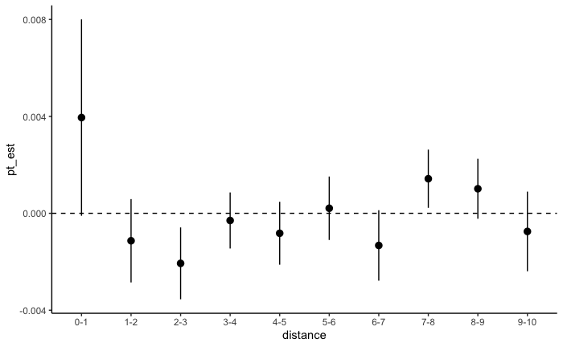

## Pollutant: PM2.5

**Notes:**

- We used data from 151 monitors and 21193 monitor-months, from 1999-01-01 to 2019-12-01
- We droppped the 29 monitor-months that had nonsensical mean monthly PM2.5 concentrations of ≤ 0 µg/m^3,

#### Crude model

```
Call:
   felm(formula = monthly_mean_pm2.5 ~ wells_prod_0to1km + wells_prod_1to2km +      wells_prod_2to3km + wells_prod_3to4km + wells_prod_4to5km +      wells_prod_5to6km + wells_prod_6to7km + wells_prod_7to8km +      wells_prod_8to9km + wells_prod_9to10km, data = subset(aqs_exposure_monthly_annuli_prod…

Residuals:
    Min      1Q  Median      3Q     Max
-17.817  -3.936  -1.312   2.259  73.102

Coefficients:
                    Estimate Std. Error t value Pr(>|t|)
(Intercept)        10.285545   0.044017 233.673  < 2e-16 ***
wells_prod_0to1km   0.012457   0.061550   0.202  0.83962
wells_prod_1to2km   0.089399   0.035327   2.531  0.01139 *
wells_prod_2to3km   0.086011   0.011719   7.340 2.21e-13 ***
wells_prod_3to4km  -0.055518   0.011768  -4.718 2.40e-06 ***
wells_prod_4to5km   0.153018   0.011144  13.731  < 2e-16 ***
wells_prod_5to6km  -0.030051   0.010004  -3.004  0.00267 **
wells_prod_6to7km   0.048558   0.007084   6.855 7.33e-12 ***
wells_prod_7to8km  -0.052374   0.003839 -13.642  < 2e-16 ***
wells_prod_8to9km   0.045987   0.006374   7.214 5.58e-13 ***
wells_prod_9to10km -0.026369   0.002643  -9.976  < 2e-16 ***
---
Signif. codes:  0 ‘***’ 0.001 ‘**’ 0.01 ‘*’ 0.05 ‘.’ 0.1 ‘ ’ 1

Residual standard error: 6.327 on 22781 degrees of freedom
Multiple R-squared(full model): 0.06329   Adjusted R-squared: 0.06288
Multiple R-squared(proj model): 0.06329   Adjusted R-squared: 0.06288
F-statistic(full model):153.9 on 10 and 22781 DF, p-value: < 2.2e-16
F-statistic(proj model): 153.9 on 10 and 22781 DF, p-value: < 2.2e-16
```

#### FE for air basin:month + year

```
Call:
   felm(formula = monthly_mean_pm2.5 ~ wells_prod_0to1km + wells_prod_1to2km +      wells_prod_2to3km + wells_prod_3to4km + wells_prod_4to5km +      wells_prod_5to6km + wells_prod_6to7km + wells_prod_7to8km +      wells_prod_8to9km + wells_prod_9to10km | factor(carb_basin):factor(month(month_year)) …

Residuals:
    Min      1Q  Median      3Q     Max
-21.371  -2.447  -0.341   1.893  75.740

Coefficients:
                    Estimate Std. Error t value Pr(>|t|)
wells_prod_0to1km  -0.076570   0.045836  -1.671  0.09483 .
wells_prod_1to2km   0.076786   0.026172   2.934  0.00335 **
wells_prod_2to3km   0.026906   0.008576   3.137  0.00171 **
wells_prod_3to4km  -0.036206   0.008605  -4.208 2.59e-05 ***
wells_prod_4to5km   0.087655   0.008108  10.810  < 2e-16 ***
wells_prod_5to6km  -0.006212   0.007595  -0.818  0.41344
wells_prod_6to7km   0.021431   0.005387   3.978 6.97e-05 ***
wells_prod_7to8km  -0.033069   0.002831 -11.681  < 2e-16 ***
wells_prod_8to9km   0.020523   0.004663   4.401 1.08e-05 ***
wells_prod_9to10km -0.005134   0.002004  -2.562  0.01040 *
---
Signif. codes:  0 ‘***’ 0.001 ‘**’ 0.01 ‘*’ 0.05 ‘.’ 0.1 ‘ ’ 1

Residual standard error: 4.581 on 22582 degrees of freedom
Multiple R-squared(full model): 0.5132   Adjusted R-squared: 0.5087
Multiple R-squared(proj model): 0.02077   Adjusted R-squared: 0.01171
F-statistic(full model):113.9 on 209 and 22582 DF, p-value: < 2.2e-16
F-statistic(proj model):  47.9 on 10 and 22582 DF, p-value: < 2.2e-16
```

#### FE for monitor + air basin-month + year

```
Call:
   felm(formula = monthly_mean_pm2.5 ~ wells_prod_0to1km + wells_prod_1to2km +      wells_prod_2to3km + wells_prod_3to4km + wells_prod_4to5km +      wells_prod_5to6km + wells_prod_6to7km + wells_prod_7to8km +      wells_prod_8to9km + wells_prod_9to10km | factor(site_id) +      factor(carb_basin):fac…

Residuals:
    Min      1Q  Median      3Q     Max
-20.276  -2.202  -0.324   1.594  74.564

Coefficients:
                    Estimate Std. Error t value Pr(>|t|)
wells_prod_0to1km  -0.234315   0.059940  -3.909 9.29e-05 ***
wells_prod_1to2km   0.220318   0.040236   5.476 4.41e-08 ***
wells_prod_2to3km  -0.037093   0.016066  -2.309  0.02097 *
wells_prod_3to4km   0.043739   0.014016   3.121  0.00181 **
wells_prod_4to5km   0.011498   0.017292   0.665  0.50610
wells_prod_5to6km   0.033246   0.015929   2.087  0.03689 *
wells_prod_6to7km   0.003173   0.011238   0.282  0.77770
wells_prod_7to8km  -0.007503   0.004065  -1.846  0.06490 .
wells_prod_8to9km   0.003758   0.008795   0.427  0.66914
wells_prod_9to10km  0.002678   0.003325   0.805  0.42062
---
Signif. codes:  0 ‘***’ 0.001 ‘**’ 0.01 ‘*’ 0.05 ‘.’ 0.1 ‘ ’ 1

Residual standard error: 4.106 on 22432 degrees of freedom
Multiple R-squared(full model): 0.6116   Adjusted R-squared: 0.6054
Multiple R-squared(proj model): 0.004224   Adjusted R-squared: -0.01171
F-statistic(full model):98.41 on 359 and 22432 DF, p-value: < 2.2e-16
F-statistic(proj model): 9.515 on 10 and 22432 DF, p-value: 5.51e-16
*** Standard errors may be too high due to more than 2 groups and exactDOF=FALSE

                          2.5 %        97.5 %
wells_prod_0to1km  -0.351801027 -0.1168292732
wells_prod_1to2km   0.141451503  0.2991837552
wells_prod_2to3km  -0.068583584 -0.0056022611
wells_prod_3to4km   0.016265894  0.0712124030
wells_prod_4to5km  -0.022395456  0.0453915287
wells_prod_5to6km   0.002024196  0.0644674079
wells_prod_6to7km  -0.018855268  0.0252009416
wells_prod_7to8km  -0.015469912  0.0004635003
wells_prod_8to9km  -0.013480437  0.0209973097
wells_prod_9to10km -0.003839866  0.0091960959
```

| distance | pt_est | ci_lower | ci_upper |
| --- | --- | --- | --- |
| 0-1 | -0.234315150 | -0.351801027 | -0.1168292732 |
| 1-2 | 0.220317629 | 0.141451503 | 0.2991837552 |
| 2-3 | -0.037092923 | -0.068583584 | -0.0056022611 |
| 3-4 | 0.043739149 | 0.016265894 | 0.0712124030 |
| 4-5 | 0.011498036 | -0.022395456 | 0.0453915287 |
| 5-6 | 0.033245802 | 0.002024196 | 0.0644674079 |
| 6-7 | 0.003172837 | -0.018855268 | 0.0252009416 |
| 7-8 | -0.007503206 | -0.015469912 | 0.0004635003 |
| 8-9 | 0.003758437 | -0.013480437 | 0.0209973097 |
| 9-10 | 0.002678115 | -0.003839866 | 0.0091960959 |

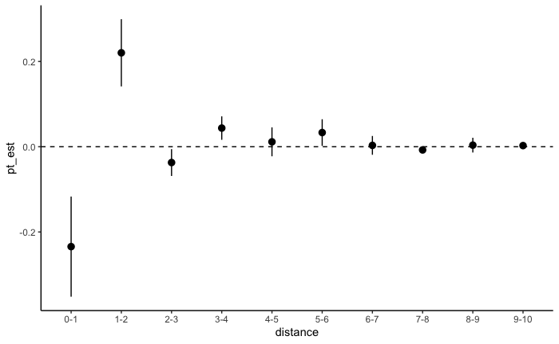

### New + Active wells

#### FE for monitor + air basin-month + year

```
the matrix is either rank-deficient or indefinitethe matrix is either rank-deficient or indefinite
```

```
Call:
   felm(formula = monthly_mean_pm2.5 ~ wells_preprod_0to1km + wells_preprod_1to2km +      wells_preprod_2to3km + wells_preprod_3to4km + wells_preprod_4to5km +      wells_preprod_5to6km + wells_preprod_6to7km + wells_preprod_7to8km +      wells_preprod_8to9km + wells_preprod_9to10km + wells_prod_0to1…

Residuals:
    Min      1Q  Median      3Q     Max
-20.259  -2.202  -0.324   1.595  74.550

Coefficients:
                        Estimate Std. Error t value Pr(>|t|)
wells_preprod_0to1km          NA         NA      NA       NA
wells_preprod_1to2km  -0.2951741  1.4312978  -0.206  0.83661
wells_preprod_2to3km   1.3639304  0.8090325   1.686  0.09183 .
wells_preprod_3to4km  -0.3859375  0.4982021  -0.775  0.43855
wells_preprod_4to5km   1.3994375  1.4905269   0.939  0.34780
wells_preprod_5to6km   1.2391810  1.4767808   0.839  0.40142
wells_preprod_6to7km  -0.1920470  0.4190158  -0.458  0.64672
wells_preprod_7to8km  -0.0453196  0.4364642  -0.104  0.91730
wells_preprod_8to9km   0.2623793  0.5277759   0.497  0.61909
wells_preprod_9to10km -0.9302842  0.3886931  -2.393  0.01670 *
wells_prod_0to1km     -0.2420938  0.0602908  -4.015 5.95e-05 ***
wells_prod_1to2km      0.2151159  0.0404223   5.322 1.04e-07 ***
wells_prod_2to3km     -0.0366541  0.0160902  -2.278  0.02273 *
wells_prod_3to4km      0.0432957  0.0140819   3.075  0.00211 **
wells_prod_4to5km      0.0197947  0.0175124   1.130  0.25835
wells_prod_5to6km      0.0309168  0.0161283   1.917  0.05526 .
wells_prod_6to7km      0.0004651  0.0113252   0.041  0.96724
wells_prod_7to8km     -0.0092424  0.0041059  -2.251  0.02440 *
wells_prod_8to9km      0.0036129  0.0088992   0.406  0.68476
wells_prod_9to10km     0.0038728  0.0033629   1.152  0.24948
---
Signif. codes:  0 ‘***’ 0.001 ‘**’ 0.01 ‘*’ 0.05 ‘.’ 0.1 ‘ ’ 1

Residual standard error: 4.105 on 22423 degrees of freedom
Multiple R-squared(full model): 0.6119   Adjusted R-squared: 0.6055
Multiple R-squared(proj model): 0.004879   Adjusted R-squared: -0.01145
F-statistic(full model):96.07 on 368 and 22423 DF, p-value: < 2.2e-16
F-statistic(proj model): 5.497 on 20 and 22423 DF, p-value: 2.215e-14
*** Standard errors may be too high due to more than 2 groups and exactDOF=FALSE
```

| distance | new_pt_est | new_ci_lower | new_ci_upper | active_pt_est | active_ci_lower | active_ci_upper |
| --- | --- | --- | --- | --- | --- | --- |
| 0-1 | NaN | NaN | NaN | -0.2420938138 | -0.3602680108 | -0.123919617 |
| 1-2 | -0.29517413 | -3.1006178 | 2.5102695 | 0.2151159102 | 0.1358853549 | 0.294346465 |
| 2-3 | 1.36393041 | -0.2218297 | 2.9496905 | -0.0366540724 | -0.0681919009 | -0.005116244 |
| 3-4 | -0.38593751 | -1.3624485 | 0.5905735 | 0.0432956964 | 0.0156942446 | 0.070897148 |
| 4-5 | 1.39943749 | -1.5220993 | 4.3209743 | 0.0197947244 | -0.0145307327 | 0.054120182 |
| 5-6 | 1.23918102 | -1.6554123 | 4.1337743 | 0.0309168273 | -0.0006957425 | 0.062529397 |
| 6-7 | -0.19204701 | -1.0133472 | 0.6292532 | 0.0004650731 | -0.0217330765 | 0.022663223 |
| 7-8 | -0.04531958 | -0.9008199 | 0.8101808 | -0.0092423538 | -0.0172902971 | -0.001194410 |
| 8-9 | 0.26237925 | -0.7720984 | 1.2968569 | 0.0036129180 | -0.0138300741 | 0.021055910 |
| 9-10 | -0.93028416 | -1.6921497 | -0.1684186 | 0.0038728384 | -0.0027186128 | 0.010464290 |

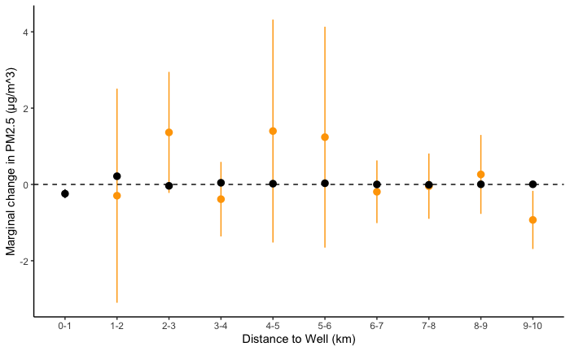

### Indicator for at least one well in the annulus

#### Crude model

```
the matrix is either rank-deficient or indefinitethe matrix is either rank-deficient or indefinite
```

```
Call:
   felm(formula = monthly_mean_pm2.5 ~ dummy_preprod_0to1km + dummy_preprod_1to2km +      dummy_preprod_2to3km + dummy_preprod_3to4km + dummy_preprod_4to5km +      dummy_preprod_5to6km + dummy_preprod_6to7km + dummy_preprod_7to8km +      dummy_preprod_8to9km + dummy_preprod_9to10km, data = subset(aq…

Residuals:
    Min      1Q  Median      3Q     Max
-17.342  -4.102  -1.384   2.331  72.765

Coefficients:
                      Estimate Std. Error t value Pr(>|t|)
(Intercept)           10.60235    0.04332 244.759  < 2e-16 ***
dummy_preprod_0to1km        NA         NA      NA       NA
dummy_preprod_1to2km   1.26498    2.19207   0.577 0.563897
dummy_preprod_2to3km   8.28751    1.68512   4.918  8.8e-07 ***
dummy_preprod_3to4km   4.01834    3.36934   1.193 0.233031
dummy_preprod_4to5km   4.21461    2.32749   1.811 0.070186 .
dummy_preprod_5to6km   7.55030    2.11719   3.566 0.000363 ***
dummy_preprod_6to7km   0.82295    1.76186   0.467 0.640441
dummy_preprod_7to8km   1.84929    1.14305   1.618 0.105706
dummy_preprod_8to9km   2.82648    1.14426   2.470 0.013513 *
dummy_preprod_9to10km  5.05604    1.47082   3.438 0.000588 ***
---
Signif. codes:  0 ‘***’ 0.001 ‘**’ 0.01 ‘*’ 0.05 ‘.’ 0.1 ‘ ’ 1

Residual standard error: 6.525 on 22782 degrees of freedom
Multiple R-squared(full model): 0.003864   Adjusted R-squared: 0.00347
Multiple R-squared(proj model): 0.003864   Adjusted R-squared: 0.00347
F-statistic(full model):9.818 on 9 and 22782 DF, p-value: 3.73e-15
F-statistic(proj model): 8.836 on 10 and 22782 DF, p-value: 1.214e-14
```

#### FE for air basin:month + year

```
the matrix is either rank-deficient or indefinitethe matrix is either rank-deficient or indefinite
```

```
Call:
   felm(formula = monthly_mean_pm2.5 ~ dummy_preprod_0to1km + dummy_preprod_1to2km +      dummy_preprod_2to3km + dummy_preprod_3to4km + dummy_preprod_4to5km +      dummy_preprod_5to6km + dummy_preprod_6to7km + dummy_preprod_7to8km +      dummy_preprod_8to9km + dummy_preprod_9to10km | factor(carb_bas…

Residuals:
    Min      1Q  Median      3Q     Max
-21.908  -2.480  -0.324   1.945  75.853

Coefficients:
                      Estimate Std. Error t value Pr(>|t|)
dummy_preprod_0to1km        NA         NA      NA       NA
dummy_preprod_1to2km   -1.1754     1.5577  -0.755 0.450504
dummy_preprod_2to3km    4.2099     1.2001   3.508 0.000452 ***
dummy_preprod_3to4km    2.1857     2.3962   0.912 0.361714
dummy_preprod_4to5km    2.2237     1.6558   1.343 0.179290
dummy_preprod_5to6km    2.8250     1.5037   1.879 0.060295 .
dummy_preprod_6to7km   -2.1100     1.2537  -1.683 0.092385 .
dummy_preprod_7to8km   -0.4306     0.8129  -0.530 0.596334
dummy_preprod_8to9km    0.2592     0.8149   0.318 0.750444
dummy_preprod_9to10km   2.4596     1.0469   2.349 0.018816 *
---
Signif. codes:  0 ‘***’ 0.001 ‘**’ 0.01 ‘*’ 0.05 ‘.’ 0.1 ‘ ’ 1

Residual standard error: 4.626 on 22583 degrees of freedom
Multiple R-squared(full model): 0.5036   Adjusted R-squared: 0.499
Multiple R-squared(proj model): 0.001285   Adjusted R-squared: -0.007913
F-statistic(full model):110.1 on 208 and 22583 DF, p-value: < 2.2e-16
F-statistic(proj model): 2.906 on 10 and 22583 DF, p-value: 0.001224
```

#### FE for monitor + air basin-month + year

```
the matrix is either rank-deficient or indefinitethe matrix is either rank-deficient or indefinite
```

```
Call:
   felm(formula = monthly_mean_pm2.5 ~ dummy_preprod_0to1km + dummy_preprod_1to2km +      dummy_preprod_2to3km + dummy_preprod_3to4km + dummy_preprod_4to5km +      dummy_preprod_5to6km + dummy_preprod_6to7km + dummy_preprod_7to8km +      dummy_preprod_8to9km + dummy_preprod_9to10km | factor(site_id)…

Residuals:
    Min      1Q  Median      3Q     Max
-20.343  -2.213  -0.328   1.608  74.596

Coefficients:
                      Estimate Std. Error t value Pr(>|t|)
dummy_preprod_0to1km        NA         NA      NA       NA
dummy_preprod_1to2km   -1.4619     1.4026  -1.042   0.2973
dummy_preprod_2to3km    1.7970     1.0937   1.643   0.1004
dummy_preprod_3to4km    0.8555     2.1382   0.400   0.6891
dummy_preprod_4to5km    1.4507     1.4811   0.980   0.3273
dummy_preprod_5to6km    0.8711     1.3498   0.645   0.5187
dummy_preprod_6to7km   -2.0276     1.1216  -1.808   0.0707 .
dummy_preprod_7to8km   -1.0234     0.7360  -1.390   0.1644
dummy_preprod_8to9km    0.2058     0.7388   0.279   0.7806
dummy_preprod_9to10km   0.1524     0.9415   0.162   0.8714
---
Signif. codes:  0 ‘***’ 0.001 ‘**’ 0.01 ‘*’ 0.05 ‘.’ 0.1 ‘ ’ 1

Residual standard error: 4.113 on 22433 degrees of freedom
Multiple R-squared(full model): 0.6102   Adjusted R-squared: 0.604
Multiple R-squared(proj model): 0.0005386   Adjusted R-squared: -0.01541
F-statistic(full model): 98.1 on 358 and 22433 DF, p-value: < 2.2e-16
F-statistic(proj model): 1.209 on 10 and 22433 DF, p-value: 0.2793
*** Standard errors may be too high due to more than 2 groups and exactDOF=FALSE
```

| distance | pt_est | ci_lower | ci_upper |
| --- | --- | --- | --- |
| 0-1 | NaN | NaN | NaN |
| 1-2 | -1.4619211 | -4.2110811 | 1.2872388 |
| 2-3 | 1.7969700 | -0.3467985 | 3.9407385 |
| 3-4 | 0.8554619 | -3.3356367 | 5.0465605 |
| 4-5 | 1.4507046 | -1.4522739 | 4.3536830 |
| 5-6 | 0.8710985 | -1.7746149 | 3.5168120 |
| 6-7 | -2.0275815 | -4.2259775 | 0.1708144 |
| 7-8 | -1.0234472 | -2.4661254 | 0.4192310 |
| 8-9 | 0.2058012 | -1.2422484 | 1.6538509 |
| 9-10 | 0.1524375 | -1.6929442 | 1.9978193 |

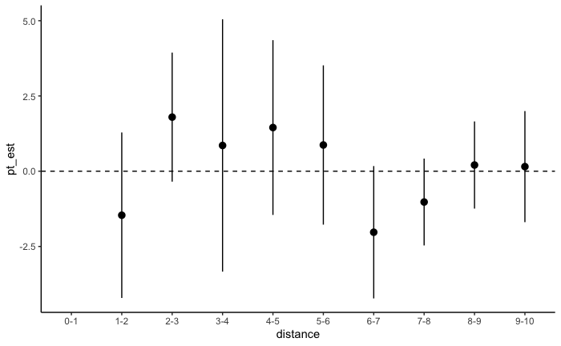

## Pollutant: PM10

**Notes:**

### Count of wells

#### Crude model

```
Call:
   felm(formula = monthly_mean_pm10 ~ wells_prod_0to1km + wells_prod_1to2km +      wells_prod_2to3km + wells_prod_3to4km + wells_prod_4to5km +      wells_prod_5to6km + wells_prod_6to7km + wells_prod_7to8km +      wells_prod_8to9km + wells_prod_9to10km, data = subset(aqs_exposure_monthly_annuli_prod,…

Residuals:
   Min     1Q Median     3Q    Max
-43.88  -9.60  -3.51   5.23 328.33

Coefficients:
                    Estimate Std. Error t value Pr(>|t|)
(Intercept)        26.172144   0.101884 256.882  < 2e-16 ***
wells_prod_0to1km   0.610292   0.044818  13.617  < 2e-16 ***
wells_prod_1to2km  -0.181736   0.019927  -9.120  < 2e-16 ***
wells_prod_2to3km   0.027847   0.010419   2.673  0.00753 **
wells_prod_3to4km   0.001957   0.010755   0.182  0.85559
wells_prod_4to5km   0.110804   0.017212   6.437 1.24e-10 ***
wells_prod_5to6km  -0.127369   0.020336  -6.263 3.84e-10 ***
wells_prod_6to7km   0.098770   0.013842   7.136 9.91e-13 ***
wells_prod_7to8km  -0.003023   0.003159  -0.957  0.33867
wells_prod_8to9km  -0.003756   0.007787  -0.482  0.62956
wells_prod_9to10km -0.002514   0.005369  -0.468  0.63959
---
Signif. codes:  0 ‘***’ 0.001 ‘**’ 0.01 ‘*’ 0.05 ‘.’ 0.1 ‘ ’ 1

Residual standard error: 15.14 on 23827 degrees of freedom
Multiple R-squared(full model): 0.04042   Adjusted R-squared: 0.04002
Multiple R-squared(proj model): 0.04042   Adjusted R-squared: 0.04002
F-statistic(full model):100.4 on 10 and 23827 DF, p-value: < 2.2e-16
F-statistic(proj model): 100.4 on 10 and 23827 DF, p-value: < 2.2e-16
```

#### FE for air basin:month + year

```
Call:
   felm(formula = monthly_mean_pm10 ~ wells_prod_0to1km + wells_prod_1to2km +      wells_prod_2to3km + wells_prod_3to4km + wells_prod_4to5km +      wells_prod_5to6km + wells_prod_6to7km + wells_prod_7to8km +      wells_prod_8to9km + wells_prod_9to10km | factor(carb_basin):factor(month(month_year)) +…

Residuals:
    Min      1Q  Median      3Q     Max
-37.578  -6.009  -1.115   4.090 312.183

Coefficients:
                    Estimate Std. Error t value Pr(>|t|)
wells_prod_0to1km   0.247382   0.033873   7.303 2.90e-13 ***
wells_prod_1to2km  -0.047691   0.015022  -3.175 0.001502 **
wells_prod_2to3km   0.013075   0.007839   1.668 0.095360 .
wells_prod_3to4km  -0.033213   0.008097  -4.102 4.11e-05 ***
wells_prod_4to5km   0.074929   0.012922   5.799 6.77e-09 ***
wells_prod_5to6km  -0.064247   0.015363  -4.182 2.90e-05 ***
wells_prod_6to7km   0.083830   0.010475   8.003 1.27e-15 ***
wells_prod_7to8km  -0.020256   0.002392  -8.469  < 2e-16 ***
wells_prod_8to9km  -0.023912   0.005963  -4.010 6.08e-05 ***
wells_prod_9to10km  0.015873   0.004094   3.877 0.000106 ***
---
Signif. codes:  0 ‘***’ 0.001 ‘**’ 0.01 ‘*’ 0.05 ‘.’ 0.1 ‘ ’ 1

Residual standard error: 11.3 on 23628 degrees of freedom
Multiple R-squared(full model):  0.47   Adjusted R-squared: 0.4653
Multiple R-squared(proj model): 0.02704   Adjusted R-squared: 0.01843
F-statistic(full model):100.3 on 209 and 23628 DF, p-value: < 2.2e-16
F-statistic(proj model): 65.67 on 10 and 23628 DF, p-value: < 2.2e-16
```

#### FE for monitor + air basin-month + year

```
Call:
   felm(formula = monthly_mean_pm10 ~ wells_prod_0to1km + wells_prod_1to2km +      wells_prod_2to3km + wells_prod_3to4km + wells_prod_4to5km +      wells_prod_5to6km + wells_prod_6to7km + wells_prod_7to8km +      wells_prod_8to9km + wells_prod_9to10km | factor(site_id) +      factor(carb_basin):fact…

Residuals:
    Min      1Q  Median      3Q     Max
-75.006  -4.872  -0.678   3.696 307.885

Coefficients:
                     Estimate Std. Error t value Pr(>|t|)
wells_prod_0to1km   0.0418046  0.0533831   0.783  0.43357
wells_prod_1to2km   0.0450617  0.0266774   1.689  0.09121 .
wells_prod_2to3km  -0.0357636  0.0124636  -2.869  0.00412 **
wells_prod_3to4km   0.0066516  0.0157513   0.422  0.67282
wells_prod_4to5km  -0.0007791  0.0195361  -0.040  0.96819
wells_prod_5to6km   0.0039710  0.0205463   0.193  0.84675
wells_prod_6to7km  -0.0105107  0.0197065  -0.533  0.59379
wells_prod_7to8km  -0.0045040  0.0054469  -0.827  0.40831
wells_prod_8to9km   0.0209657  0.0164490   1.275  0.20247
wells_prod_9to10km  0.0277547  0.0069701   3.982 6.86e-05 ***
---
Signif. codes:  0 ‘***’ 0.001 ‘**’ 0.01 ‘*’ 0.05 ‘.’ 0.1 ‘ ’ 1

Residual standard error: 9.251 on 23466 degrees of freedom
Multiple R-squared(full model): 0.6473   Adjusted R-squared: 0.6417
Multiple R-squared(proj model): 0.002838   Adjusted R-squared: -0.01293
F-statistic(full model):116.1 on 371 and 23466 DF, p-value: < 2.2e-16
F-statistic(proj model): 6.679 on 10 and 23466 DF, p-value: 1.912e-10
*** Standard errors may be too high due to more than 2 groups and exactDOF=FALSE
```

| distance | pt_est | ci_lower | ci_upper |
| --- | --- | --- | --- |
| 0-1 | 0.0418045567 | -0.06282978 | 0.146438896 |
| 1-2 | 0.0450617346 | -0.00722777 | 0.097351239 |
| 2-3 | -0.0357636168 | -0.06019306 | -0.011334176 |
| 3-4 | 0.0066516324 | -0.02422190 | 0.037525167 |
| 4-5 | -0.0007790922 | -0.03907114 | 0.037512959 |
| 5-6 | 0.0039710415 | -0.03630110 | 0.044243179 |
| 6-7 | -0.0105106803 | -0.04913668 | 0.028115323 |
| 7-8 | -0.0045039560 | -0.01518030 | 0.006172391 |
| 8-9 | 0.0209657162 | -0.01127541 | 0.053206846 |
| 9-10 | 0.0277546643 | 0.01409287 | 0.041416458 |

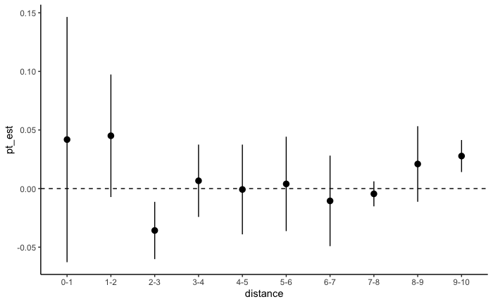

### New + Active wells

#### FE for monitor + air basin-month + year

```
There were 36 warnings (use warnings() to see them)
```

```
Call:
   felm(formula = monthly_mean_pm10 ~ wells_preprod_0to1km + wells_preprod_1to2km +      wells_preprod_2to3km + wells_preprod_3to4km + wells_preprod_4to5km +      wells_preprod_5to6km + wells_preprod_6to7km + wells_preprod_7to8km +      wells_preprod_8to9km + wells_preprod_9to10km + wells_prod_0to1k…

Residuals:
    Min      1Q  Median      3Q     Max
-75.017  -4.873  -0.678   3.698 307.868

Coefficients:
                        Estimate Std. Error t value Pr(>|t|)
wells_preprod_0to1km  -1.6524920  1.5814866  -1.045  0.29608
wells_preprod_1to2km  -0.2264774  0.6117579  -0.370  0.71123
wells_preprod_2to3km  -3.0257955  1.1519457  -2.627  0.00863 **
wells_preprod_3to4km   0.0396155  0.5488667   0.072  0.94246
wells_preprod_4to5km  -0.2738858  0.9483297  -0.289  0.77273
wells_preprod_5to6km   0.2452074  0.7555640   0.325  0.74554
wells_preprod_6to7km  -0.8439569  0.4221621  -1.999  0.04561 *
wells_preprod_7to8km   0.8023699  0.7078768   1.133  0.25702
wells_preprod_8to9km   1.0770706  0.9921091   1.086  0.27765
wells_preprod_9to10km -1.4494389  0.7827320  -1.852  0.06407 .
wells_prod_0to1km      0.0683129  0.0553578   1.234  0.21721
wells_prod_1to2km      0.0361122  0.0273570   1.320  0.18684
wells_prod_2to3km     -0.0356166  0.0125379  -2.841  0.00451 **
wells_prod_3to4km      0.0009035  0.0159089   0.057  0.95471
wells_prod_4to5km      0.0120271  0.0202362   0.594  0.55229
wells_prod_5to6km      0.0020290  0.0206243   0.098  0.92163
wells_prod_6to7km     -0.0204491  0.0204187  -1.001  0.31660
wells_prod_7to8km     -0.0047438  0.0054690  -0.867  0.38573
wells_prod_8to9km      0.0200612  0.0165725   1.211  0.22610
wells_prod_9to10km     0.0301201  0.0070701   4.260 2.05e-05 ***
---
Signif. codes:  0 ‘***’ 0.001 ‘**’ 0.01 ‘*’ 0.05 ‘.’ 0.1 ‘ ’ 1

Residual standard error: 9.248 on 23456 degrees of freedom
Multiple R-squared(full model): 0.6476   Adjusted R-squared: 0.6419
Multiple R-squared(proj model): 0.003739   Adjusted R-squared: -0.01244
F-statistic(full model):113.1 on 381 and 23456 DF, p-value: < 2.2e-16
F-statistic(proj model): 4.402 on 20 and 23456 DF, p-value: 1.723e-10
*** Standard errors may be too high due to more than 2 groups and exactDOF=FALSE
```

| distance | new_pt_est | new_ci_lower | new_ci_upper | active_pt_est | active_ci_lower | active_ci_upper |
| --- | --- | --- | --- | --- | --- | --- |
| 0-1 | -1.65249195 | -4.7523088 | 1.44732487 | 0.0683128524 | -0.04019201 | 0.176817711 |
| 1-2 | -0.22647735 | -1.4255628 | 0.97260805 | 0.0361122068 | -0.01750925 | 0.089733668 |
| 2-3 | -3.02579549 | -5.2836841 | -0.76790686 | -0.0356166214 | -0.06019181 | -0.011041437 |
| 3-4 | 0.03961551 | -1.0361991 | 1.11543008 | 0.0009034875 | -0.03027904 | 0.032086019 |
| 4-5 | -0.27388583 | -2.1326738 | 1.58490217 | 0.0120270764 | -0.02763728 | 0.051691433 |
| 5-6 | 0.24520739 | -1.2357473 | 1.72616209 | 0.0020290442 | -0.03839585 | 0.042453941 |
| 6-7 | -0.84395693 | -1.6714222 | -0.01649168 | -0.0204491391 | -0.06047108 | 0.019572804 |
| 7-8 | 0.80236991 | -0.5851147 | 2.18985451 | -0.0047437817 | -0.01546336 | 0.005975801 |
| 8-9 | 1.07707056 | -0.8675279 | 3.02166897 | 0.0200611746 | -0.01242197 | 0.052544321 |
| 9-10 | -1.44943894 | -2.9836447 | 0.08476678 | 0.0301200770 | 0.01626213 | 0.043978025 |

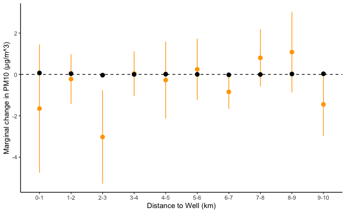

### Indicator for at least one well in the annulus

#### Crude model

```
Call:
   felm(formula = monthly_mean_pm10 ~ dummy_preprod_0to1km + dummy_preprod_1to2km +      dummy_preprod_2to3km + dummy_preprod_3to4km + dummy_preprod_4to5km +      dummy_preprod_5to6km + dummy_preprod_6to7km + dummy_preprod_7to8km +      dummy_preprod_8to9km + dummy_preprod_9to10km, data = subset(aqs…

Residuals:
   Min     1Q Median     3Q    Max
-29.67  -9.82  -3.72   5.44 327.88

Coefficients:
                      Estimate Std. Error t value Pr(>|t|)
(Intercept)            26.6216     0.1003 265.428  < 2e-16 ***
dummy_preprod_0to1km   -3.1168     5.6767  -0.549 0.582980
dummy_preprod_1to2km    9.5179     2.5350   3.755 0.000174 ***
dummy_preprod_2to3km    4.9992     2.9879   1.673 0.094305 .
dummy_preprod_3to4km    8.0007     2.6588   3.009 0.002622 **
dummy_preprod_4to5km    1.5007     2.6670   0.563 0.573652
dummy_preprod_5to6km    5.0521     2.6034   1.941 0.052324 .
dummy_preprod_6to7km    5.5101     2.3711   2.324 0.020141 *
dummy_preprod_7to8km    0.8840     2.5168   0.351 0.725424
dummy_preprod_8to9km    4.1785     2.2259   1.877 0.060498 .
dummy_preprod_9to10km  10.1964     2.9745   3.428 0.000609 ***
---
Signif. codes:  0 ‘***’ 0.001 ‘**’ 0.01 ‘*’ 0.05 ‘.’ 0.1 ‘ ’ 1

Residual standard error: 15.42 on 23827 degrees of freedom
Multiple R-squared(full model): 0.004512   Adjusted R-squared: 0.004094
Multiple R-squared(proj model): 0.004512   Adjusted R-squared: 0.004094
F-statistic(full model): 10.8 on 10 and 23827 DF, p-value: < 2.2e-16
F-statistic(proj model):  10.8 on 10 and 23827 DF, p-value: < 2.2e-16
```

#### FE for air basin:month + year

```
Call:
   felm(formula = monthly_mean_pm10 ~ dummy_preprod_0to1km + dummy_preprod_1to2km +      dummy_preprod_2to3km + dummy_preprod_3to4km + dummy_preprod_4to5km +      dummy_preprod_5to6km + dummy_preprod_6to7km + dummy_preprod_7to8km +      dummy_preprod_8to9km + dummy_preprod_9to10km | factor(carb_basi…

Residuals:
    Min      1Q  Median      3Q     Max
-38.162  -6.073  -1.178   4.121 313.228

Coefficients:
                      Estimate Std. Error t value Pr(>|t|)
dummy_preprod_0to1km    -5.753      4.223  -1.362 0.173164
dummy_preprod_1to2km     6.001      1.888   3.179 0.001478 **
dummy_preprod_2to3km     3.911      2.224   1.759 0.078595 .
dummy_preprod_3to4km     2.742      1.978   1.386 0.165618
dummy_preprod_4to5km     1.883      1.985   0.948 0.342907
dummy_preprod_5to6km     2.359      1.937   1.218 0.223318
dummy_preprod_6to7km     1.096      1.767   0.620 0.535061
dummy_preprod_7to8km    -1.774      1.874  -0.947 0.343795
dummy_preprod_8to9km     0.230      1.661   0.139 0.889831
dummy_preprod_9to10km    7.457      2.214   3.368 0.000759 ***
---
Signif. codes:  0 ‘***’ 0.001 ‘**’ 0.01 ‘*’ 0.05 ‘.’ 0.1 ‘ ’ 1

Residual standard error: 11.44 on 23628 degrees of freedom
Multiple R-squared(full model): 0.4564   Adjusted R-squared: 0.4516
Multiple R-squared(proj model): 0.002096   Adjusted R-squared: -0.006731
F-statistic(full model):94.93 on 209 and 23628 DF, p-value: < 2.2e-16
F-statistic(proj model): 4.962 on 10 and 23628 DF, p-value: 3.188e-07
```

#### FE for monitor + air basin-month + year

```
Call:
   felm(formula = monthly_mean_pm10 ~ dummy_preprod_0to1km + dummy_preprod_1to2km +      dummy_preprod_2to3km + dummy_preprod_3to4km + dummy_preprod_4to5km +      dummy_preprod_5to6km + dummy_preprod_6to7km + dummy_preprod_7to8km +      dummy_preprod_8to9km + dummy_preprod_9to10km | factor(site_id) …

Residuals:
    Min      1Q  Median      3Q     Max
-75.012  -4.872  -0.667   3.694 307.865

Coefficients:
                      Estimate Std. Error t value Pr(>|t|)
dummy_preprod_0to1km   -4.5830     3.4196  -1.340   0.1802
dummy_preprod_1to2km    2.7044     1.5720   1.720   0.0854 .
dummy_preprod_2to3km    0.5513     1.8199   0.303   0.7619
dummy_preprod_3to4km    0.7962     1.6264   0.490   0.6245
dummy_preprod_4to5km   -0.3479     1.6214  -0.215   0.8301
dummy_preprod_5to6km   -1.2784     1.5831  -0.808   0.4194
dummy_preprod_6to7km   -1.0603     1.4526  -0.730   0.4654
dummy_preprod_7to8km   -0.1575     1.5528  -0.101   0.9192
dummy_preprod_8to9km    1.7237     1.3840   1.245   0.2130
dummy_preprod_9to10km   1.8715     1.8277   1.024   0.3059
---
Signif. codes:  0 ‘***’ 0.001 ‘**’ 0.01 ‘*’ 0.05 ‘.’ 0.1 ‘ ’ 1

Residual standard error: 9.262 on 23466 degrees of freedom
Multiple R-squared(full model): 0.6464   Adjusted R-squared: 0.6408
Multiple R-squared(proj model): 0.0003943   Adjusted R-squared: -0.01541
F-statistic(full model):115.6 on 371 and 23466 DF, p-value: < 2.2e-16
F-statistic(proj model): 0.9256 on 10 and 23466 DF, p-value: 0.508
*** Standard errors may be too high due to more than 2 groups and exactDOF=FALSE
```

| distance | pt_est | ci_lower | ci_upper |
| --- | --- | --- | --- |
| 0-1 | -4.5829594 | -11.2855135 | 2.119595 |
| 1-2 | 2.7044282 | -0.3768772 | 5.785734 |
| 2-3 | 0.5512881 | -3.0158017 | 4.118378 |
| 3-4 | 0.7961591 | -2.3916038 | 3.983922 |
| 4-5 | -0.3478661 | -3.5258436 | 2.830111 |
| 5-6 | -1.2783866 | -4.3812801 | 1.824507 |
| 6-7 | -1.0602763 | -3.9074675 | 1.786915 |
| 7-8 | -0.1574547 | -3.2011095 | 2.886200 |
| 8-9 | 1.7237204 | -0.9889428 | 4.436384 |
| 9-10 | 1.8714822 | -1.7108875 | 5.453852 |

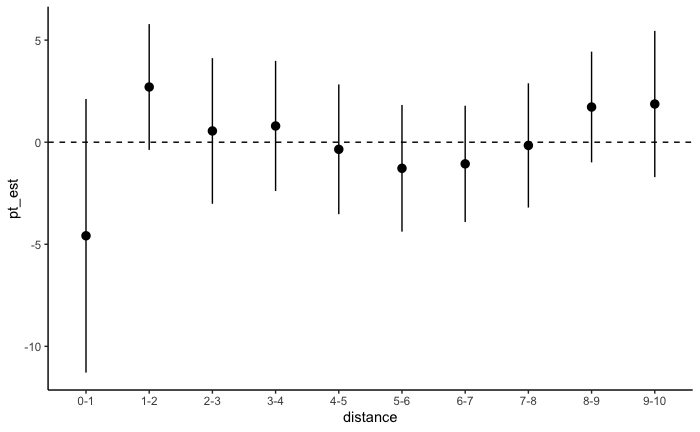